# ANOVA test for registro_formal

Geiser C. Challco geiser@alumni.usp.br

- ANOVA: registro_formal ~ time
  - Data Preparation
  - Summary Statistics
  - ANOVA Computation
  - PairWise Computation
- ANOVA: registro_formal ~ time*gender + Error(id/time)
  - Data Preparation
    - Check assumptions: Identifying Outliers
    - Check assumptions: Normality Test
    - Summary Statistics
  - ANOVA Computation
  - ANOVA Computation after removing non.normal data
  - PairWise Computation
  - PairWise Computation after removing non.normal data
- ANOVA: registro_formal ~ time*localizacao + Error(id/time)
  - Data Preparation
    - Check assumptions: Identifying Outliers
    - Check assumptions: Normality Test
    - Summary Statistics
  - ANOVA Computation
  - ANOVA Computation after removing non.normal data
  - PairWise Computation
  - PairWise Computation after removing non.normal data
- ANOVA: registro_formal ~ time*regiao + Error(id/time)
  - Data Preparation
    - Check assumptions: Identifying Outliers
    - Check assumptions: Normality Test
    - Summary Statistics
  - ANOVA Computation
  - ANOVA Computation after removing non.normal data
  - PairWise Computation
  - PairWise Computation after removing non.normal data
- ANOVA: registro_formal ~ time*porte + Error(id/time)
  - Data Preparation
    - Check assumptions: Identifying Outliers
    - Check assumptions: Normality Test
    - Summary Statistics
  - ANOVA Computation
  - ANOVA Computation after removing non.normal data
  - PairWise Computation
  - PairWise Computation after removing non.normal data

```r
dat <- read_excel("../data/data.xlsx", sheet = "alunos_ef59")

escolas <- read_excel("../data/data.xlsx", sheet = "escolas")
edat <- merge(dat, escolas, by = "cod_escola", all.x = T)
```

# ANOVA: registro_formal ~ time

## Data Preparation

```r
data <- edat[,c("aluno_id","ciclo","registro_formal")]
data <- data[data$ciclo %in% c("Primeiro Ciclo","Terceiro Ciclo"),]
data$ciclo <- factor(data$ciclo, c("Primeiro Ciclo","Terceiro Ciclo"))
data <- unique(data)

wdat <- spread(data, ciclo, registro_formal)
wdat <- wdat[complete.cases(wdat),]
colnames(wdat) <- c("id","c1","c3")

ldat <- gather(wdat, key = time, value = registro_formal, c1,c3) %>%
  convert_as_factor(id, time)
ldat <- rshinystatistics::remove_group_data(ldat, "registro_formal", "time", n.limit = 30)
```

## Summary Statistics

```r
(sdat <- ldat %>% group_by(time) %>%
   get_summary_stats(registro_formal, type = "mean_sd"))
```

```
## # A tibble: 2 × 5
##   time  variable            n  mean    sd
##   <fct> <fct>           <dbl> <dbl> <dbl>
## 1 c1    registro_formal  3997  1.89 0.688
## 2 c3    registro_formal  3997  1.82 0.732
```

| time | variable | n | mean | sd |
| --- | --- | --- | --- | --- |
| c1 | registro_formal | 3997 | 1.889 | 0.688 |
| c3 | registro_formal | 3997 | 1.821 | 0.732 |

## ANOVA Computation

```r
(res.aov <- anova_test(ldat, dv = registro_formal, wid = id, within = time))
```

```
## ANOVA Table (type III tests)
##
##   Effect DFn  DFd     F       p p<.05   ges
## 1   time   1 3996 20.39 6.5e-06     * 0.002
```

## PairWise Computation

```r
(pwc <- ldat %>% emmeans_test(registro_formal ~ time, detailed = T, p.adjust.method = "bonferroni"))
```

```
## # A tibble: 1 × 14
##   term  .y.    group1 group2 null.value estimate     se    df conf.low conf.high
## * <chr> <chr>  <chr>  <chr>       <dbl>    <dbl>  <dbl> <dbl>    <dbl>     <dbl>
## 1 time  regis… c1     c3              0   0.0679 0.0159  7992   0.0368    0.0991
## # ℹ 4 more variables: statistic <dbl>, p <dbl>, p.adj <dbl>, p.adj.signif <chr>
```

| term | .y. | group1 | group2 | null.value | estimate | se | df | conf.low | conf.high | statistic | p | p.adj | p.adj.signif |
| --- | --- | --- | --- | --- | --- | --- | --- | --- | --- | --- | --- | --- | --- |
| time | registro_formal | c1 | c3 | 0 | 0.068 | 0.016 | 7992 | 0.037 | 0.099 | 4.276 | 0 | 0 | **** |

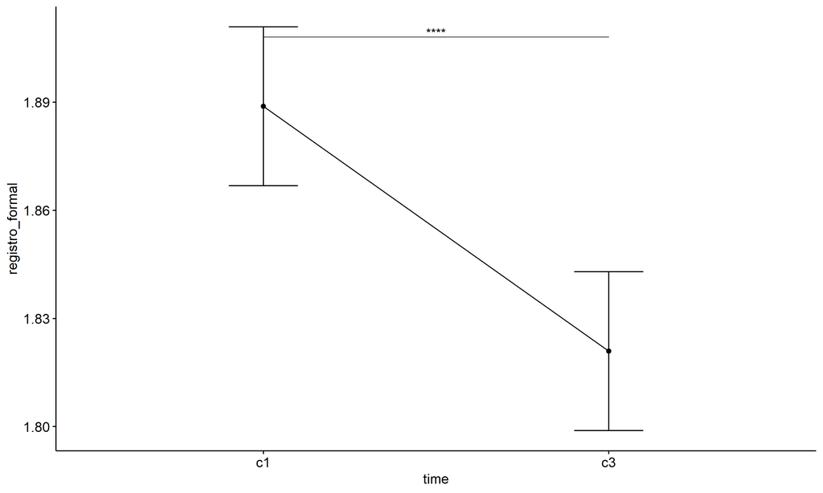

```r
pwc <- add_xy_position(pwc, x = "time", fun = "mean_se")
ggline(get_emmeans(pwc), x = "time", y = "emmean", ylab = "registro_formal") +
  geom_errorbar(aes(ymin = conf.low, ymax = conf.high), width = 0.2) +
  stat_pvalue_manual(pwc, hide.ns = T, tip.length = F)
```

# ANOVA: registro_formal ~ time*gender + Error(id/time)

## Data Preparation

```r
data <- edat[,c("aluno_id","gender","ciclo","registro_formal")]
data <- data[data$ciclo %in% c("Primeiro Ciclo","Terceiro Ciclo"),]
data$ciclo <- factor(data$ciclo, c("Primeiro Ciclo","Terceiro Ciclo"))
data <- unique(data)

wdat <- spread(data, ciclo, registro_formal)
wdat <- wdat[complete.cases(wdat),]
colnames(wdat) <- c("id","gender","c1","c3")

ldat <- gather(wdat, key = time, value = registro_formal, c1,c3) %>%
  convert_as_factor(id, time)
ldat <- remove_group_data(ldat, "registro_formal", c("time", "gender"), n.limit = 30)
ldat$gender <- factor(ldat$gender, sort(unique(ldat$gender)))
```

### Check assumptions: Identifying Outliers

```r
outliers <- identify_outliers(group_by(ldat, time, gender), registro_formal)
(outliers <- outliers[outliers$is.extreme == T,])
```

```
## # A tibble: 20 × 6
##    gender time  id                   registro_formal is.outlier is.extreme
##    <fct>  <fct> <fct>                          <dbl> <lgl>      <lgl>
##  1 Male   c1    8zkBFEUAFkixLZcY9EP0               4 TRUE       TRUE
##  2 Male   c1    baitWvlruSoQV9MUrIgr               4 TRUE       TRUE
##  3 Male   c1    IS6H8SGCc2Qi3Sc76Hdu               4 TRUE       TRUE
##  4 Male   c1    iyHsVjMJJRSYypImpewF               4 TRUE       TRUE
##  5 Male   c1    K7BVRqiiNsRjisKvt85x               4 TRUE       TRUE
##  6 Male   c1    KaCG3CroQpZookJ14Oed               4 TRUE       TRUE
##  7 Male   c1    kG5EWNlF7iFys7u9NU2S               4 TRUE       TRUE
##  8 Male   c1    kNBsYSydO1Ohmh5OxN1R               4 TRUE       TRUE
##  9 Male   c1    KsNDea9pyWSqZNmzKPcL               4 TRUE       TRUE
## 10 Male   c1    KxutDWOwf7c7zs3WzsVK               4 TRUE       TRUE
## 11 Male   c1    lcQkFKelmfF3AvUDkp2E               4 TRUE       TRUE
## 12 Male   c1    oCdc6ouxkfn0i0Q5NmmU               4 TRUE       TRUE
## 13 Male   c1    sIoy2GB8m7C2p6qtFBB4               4 TRUE       TRUE
## 14 Male   c1    SshX9BXtzAfFlsOTZAid               4 TRUE       TRUE
## 15 Male   c1    tbaJOm2fecWIzyknkmjZ               4 TRUE       TRUE
## 16 Male   c1    UqLUlHER7l3QQ8FNufkX               4 TRUE       TRUE
## 17 Male   c1    VBdctSnsWQ6Xz1eKn53t               4 TRUE       TRUE
## 18 Male   c1    wgVofz459XsBlqQs3fln               4 TRUE       TRUE
## 19 Male   c1    WliDxeLsUXTgNB5sq98e               4 TRUE       TRUE
## 20 Male   c1    YpnkzyPiMacKwl1V5xUY               4 TRUE       TRUE
```

| gender | time | id | registro_formal | is.outlier | is.extreme |
| --- | --- | --- | --- | --- | --- |
| Male | c1 | 8zkBFEUAFkixLZcY9EP0 | 4 | TRUE | TRUE |
| Male | c1 | baitWvlruSoQV9MUrIgr | 4 | TRUE | TRUE |
| Male | c1 | IS6H8SGCc2Qi3Sc76Hdu | 4 | TRUE | TRUE |
| Male | c1 | iyHsVjMJJRSYypImpewF | 4 | TRUE | TRUE |
| Male | c1 | K7BVRqiiNsRjisKvt85x | 4 | TRUE | TRUE |
| Male | c1 | KaCG3CroQpZookJ14Oed | 4 | TRUE | TRUE |
| Male | c1 | kG5EWNlF7iFys7u9NU2S | 4 | TRUE | TRUE |
| Male | c1 | kNBsYSydO1Ohmh5OxN1R | 4 | TRUE | TRUE |
| Male | c1 | KsNDea9pyWSqZNmzKPcL | 4 | TRUE | TRUE |
| Male | c1 | KxutDWOwf7c7zs3WzsVK | 4 | TRUE | TRUE |
| Male | c1 | lcQkFKelmfF3AvUDkp2E | 4 | TRUE | TRUE |
| Male | c1 | oCdc6ouxkfn0i0Q5NmmU | 4 | TRUE | TRUE |
| Male | c1 | sIoy2GB8m7C2p6qtFBB4 | 4 | TRUE | TRUE |
| Male | c1 | SshX9BXtzAfFlsOTZAid | 4 | TRUE | TRUE |
| Male | c1 | tbaJOm2fecWIzyknkmjZ | 4 | TRUE | TRUE |
| Male | c1 | UqLUlHER7l3QQ8FNufkX | 4 | TRUE | TRUE |
| Male | c1 | VBdctSnsWQ6Xz1eKn53t | 4 | TRUE | TRUE |
| Male | c1 | wgVofz459XsBlqQs3fln | 4 | TRUE | TRUE |
| Male | c1 | WliDxeLsUXTgNB5sq98e | 4 | TRUE | TRUE |
| Male | c1 | YpnkzyPiMacKwl1V5xUY | 4 | TRUE | TRUE |

### Check assumptions: Normality Test

```r
(normality.df <- normality.test.per.groups(ldat, "registro_formal", c("time", "gender")))
```

```
##               var        variable time gender    n  skewness    kurtosis
## 1 registro_formal registro_formal   c1 Female 1880 0.4434370 -0.35878735
## 2 registro_formal registro_formal   c1   Male 1927 0.5718729 -0.03870002
## 3 registro_formal registro_formal   c3 Female 1880 0.5313224 -0.18890043
## 4 registro_formal registro_formal   c3   Male 1927 0.6208678 -0.18124009
##   symmetry statistic     method            p p.signif normality
## 1      YES  71.28458 D'Agostino 3.330669e-16     ****         -
## 2       NO  92.31754 D'Agostino 0.000000e+00     ****         -
## 3       NO  82.06028 D'Agostino 0.000000e+00     ****         -
## 4       NO 109.30168 D'Agostino 0.000000e+00     ****         -
```

| var | variable | time | gender | n | skewness | kurtosis | symmetry | statistic | method | p | p.signif | normality |
| --- | --- | --- | --- | --- | --- | --- | --- | --- | --- | --- | --- | --- |
| registro_formal | registro_formal | c1 | Female | 1880 | 0.443 | -0.359 | YES | 71.285 | D’Agostino | 0 | **** | - |
| registro_formal | registro_formal | c1 | Male | 1927 | 0.572 | -0.039 | NO | 92.318 | D’Agostino | 0 | **** | - |
| registro_formal | registro_formal | c3 | Female | 1880 | 0.531 | -0.189 | NO | 82.060 | D’Agostino | 0 | **** | - |
| registro_formal | registro_formal | c3 | Male | 1927 | 0.621 | -0.181 | NO | 109.302 | D’Agostino | 0 | **** | - |

```r
(non.ids <- unique(do.call(
  c, lapply(which(normality.df$normality == 'NO'), FUN = function(i) {
  idx = which(ldat$time == normality.df$time[i] &
                ldat$gender == normality.df$gender[i])
  getNonNormal(ldat$"registro_formal"[idx], ldat$id[idx])
}))))
```

```r
if (length(non.ids) > 0)
  ldat2 <- ldat[!ldat$id %in% non.ids,]
```

### Summary Statistics

```r
(sdat <- ldat %>% group_by(time, gender) %>%
   get_summary_stats(registro_formal, type = "mean_sd"))
```

```
## # A tibble: 4 × 6
##   gender time  variable            n  mean    sd
##   <fct>  <fct> <fct>           <dbl> <dbl> <dbl>
## 1 Female c1    registro_formal  1880  1.92 0.702
## 2 Male   c1    registro_formal  1927  1.86 0.676
## 3 Female c3    registro_formal  1880  1.84 0.721
## 4 Male   c3    registro_formal  1927  1.80 0.736
```

| gender | time | variable | n | mean | sd |
| --- | --- | --- | --- | --- | --- |
| Female | c1 | registro_formal | 1880 | 1.917 | 0.702 |
| Male | c1 | registro_formal | 1927 | 1.862 | 0.676 |
| Female | c3 | registro_formal | 1880 | 1.840 | 0.721 |
| Male | c3 | registro_formal | 1927 | 1.801 | 0.736 |

```r
if (length(non.ids) > 0)
  (sdat <- ldat2 %>% group_by(time, gender) %>%
      get_summary_stats(registro_formal, type = "mean_sd"))
```

| gender | time | variable | n | mean | sd |
| --- | --- | --- | --- | --- | --- |
| Female | c1 | registro_formal | 1880 | 1.917 | 0.702 |
| Male | c1 | registro_formal | 1927 | 1.862 | 0.676 |
| Female | c3 | registro_formal | 1880 | 1.840 | 0.721 |
| Male | c3 | registro_formal | 1927 | 1.801 | 0.736 |

## ANOVA Computation

```r
(res.aov <- anova_test(ldat, dv = registro_formal, wid = id, between = gender, within = time))
```

```
## ANOVA Table (type III tests)
##
##        Effect DFn  DFd      F        p p<.05      ges
## 1      gender   1 3805  7.643 6.00e-03     * 1.00e-03
## 2        time   1 3805 20.047 7.78e-06     * 2.00e-03
## 3 gender:time   1 3805  0.294 5.88e-01       3.48e-05
```

## ANOVA Computation after removing non.normal data

```r
if (length(non.ids) > 0)
  (res.aov2 <- anova_test(ldat2, dv = registro_formal, wid = id, between = gender , within = time))
```

## PairWise Computation

```r
(pwc <- ldat %>% group_by(time) %>%
   emmeans_test(registro_formal ~ gender, detailed = T, p.adjust.method = "bonferroni"))
```

```
## # A tibble: 2 × 15
##   time  term   .y.       group1 group2 null.value estimate     se    df conf.low
## * <fct> <chr>  <chr>     <chr>  <chr>       <dbl>    <dbl>  <dbl> <dbl>    <dbl>
## 1 c1    gender registro… Female Male            0   0.0555 0.0230  7610  0.0104
## 2 c3    gender registro… Female Male            0   0.0387 0.0230  7610 -0.00632
## # ℹ 5 more variables: conf.high <dbl>, statistic <dbl>, p <dbl>, p.adj <dbl>,
## #   p.adj.signif <chr>
```

| time | term | .y. | group1 | group2 | null.value | estimate | se | df | conf.low | conf.high | statistic | p | p.adj | p.adj.signif |
| --- | --- | --- | --- | --- | --- | --- | --- | --- | --- | --- | --- | --- | --- | --- |
| c1 | gender | registro_formal | Female | Male | 0 | 0.055 | 0.023 | 7610 | 0.010 | 0.101 | 2.413 | 0.016 | 0.016 | * |
| c3 | gender | registro_formal | Female | Male | 0 | 0.039 | 0.023 | 7610 | -0.006 | 0.084 | 1.685 | 0.092 | 0.092 | ns |

```r
(emms <- get_emmeans(pwc))
```

```
## # A tibble: 4 × 8
##   time  gender emmean     se    df conf.low conf.high method
##   <fct> <fct>   <dbl>  <dbl> <dbl>    <dbl>     <dbl> <chr>
## 1 c1    Female   1.92 0.0164  7610     1.89      1.95 Emmeans test
## 2 c1    Male     1.86 0.0161  7610     1.83      1.89 Emmeans test
## 3 c3    Female   1.84 0.0164  7610     1.81      1.87 Emmeans test
## 4 c3    Male     1.80 0.0161  7610     1.77      1.83 Emmeans test
```

| time | gender | emmean | se | df | conf.low | conf.high | method |
| --- | --- | --- | --- | --- | --- | --- | --- |
| c1 | Female | 1.917 | 0.016 | 7610 | 1.885 | 1.949 | Emmeans test |
| c1 | Male | 1.862 | 0.016 | 7610 | 1.830 | 1.893 | Emmeans test |
| c3 | Female | 1.840 | 0.016 | 7610 | 1.808 | 1.872 | Emmeans test |
| c3 | Male | 1.801 | 0.016 | 7610 | 1.769 | 1.833 | Emmeans test |

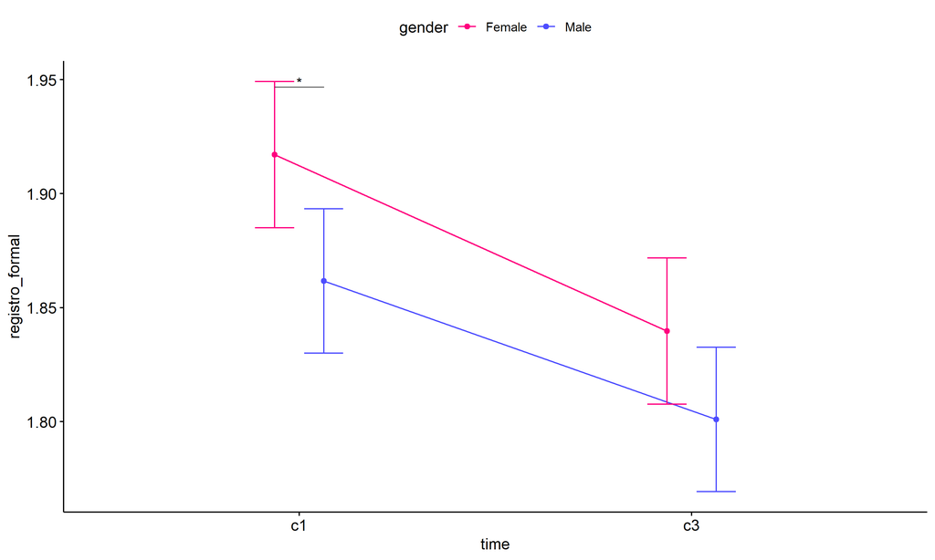

```r
pwc <- add_xy_position(pwc, x = "time", fun = "mean_se", dodge = 0.25)
pd <- position_dodge(width = 0.25)
ggline(emms, x = "time", y = "emmean", color = "gender",
       palette = c("#FF007F","#4D4DFF"),
       position = pd, ylab = "registro_formal") +
  geom_errorbar(aes(ymin = conf.low, ymax = conf.high, color = gender),
                position = pd, width = 0.2) +
  stat_pvalue_manual(pwc, hide.ns = T, tip.length = F, linetype = 1)
```

```r
(pwc <- ldat %>% group_by(gender) %>%
    emmeans_test(registro_formal ~ time, detailed = T, p.adjust.method = "bonferroni"))
```

```
## # A tibble: 2 × 15
##   gender term  .y.       group1 group2 null.value estimate     se    df conf.low
## * <fct>  <chr> <chr>     <chr>  <chr>       <dbl>    <dbl>  <dbl> <dbl>    <dbl>
## 1 Female time  registro… c1     c3              0   0.0774 0.0231  7610   0.0321
## 2 Male   time  registro… c1     c3              0   0.0607 0.0228  7610   0.0159
## # ℹ 5 more variables: conf.high <dbl>, statistic <dbl>, p <dbl>, p.adj <dbl>,
## #   p.adj.signif <chr>
```

| gender | term | .y. | group1 | group2 | null.value | estimate | se | df | conf.low | conf.high | statistic | p | p.adj | p.adj.signif |
| --- | --- | --- | --- | --- | --- | --- | --- | --- | --- | --- | --- | --- | --- | --- |
| Female | time | registro_formal | c1 | c3 | 0 | 0.077 | 0.023 | 7610 | 0.032 | 0.123 | 3.349 | 0.001 | 0.001 | *** |
| Male | time | registro_formal | c1 | c3 | 0 | 0.061 | 0.023 | 7610 | 0.016 | 0.105 | 2.658 | 0.008 | 0.008 | ** |

```r
(emms <- get_emmeans(pwc))
```

```
## # A tibble: 4 × 8
##   gender time  emmean     se    df conf.low conf.high method
##   <fct>  <fct>  <dbl>  <dbl> <dbl>    <dbl>     <dbl> <chr>
## 1 Female c1      1.92 0.0164  7610     1.89      1.95 Emmeans test
## 2 Female c3      1.84 0.0164  7610     1.81      1.87 Emmeans test
## 3 Male   c1      1.86 0.0161  7610     1.83      1.89 Emmeans test
## 4 Male   c3      1.80 0.0161  7610     1.77      1.83 Emmeans test
```

| gender | time | emmean | se | df | conf.low | conf.high | method |
| --- | --- | --- | --- | --- | --- | --- | --- |
| Female | c1 | 1.917 | 0.016 | 7610 | 1.885 | 1.949 | Emmeans test |
| Female | c3 | 1.840 | 0.016 | 7610 | 1.808 | 1.872 | Emmeans test |
| Male | c1 | 1.862 | 0.016 | 7610 | 1.830 | 1.893 | Emmeans test |
| Male | c3 | 1.801 | 0.016 | 7610 | 1.769 | 1.833 | Emmeans test |

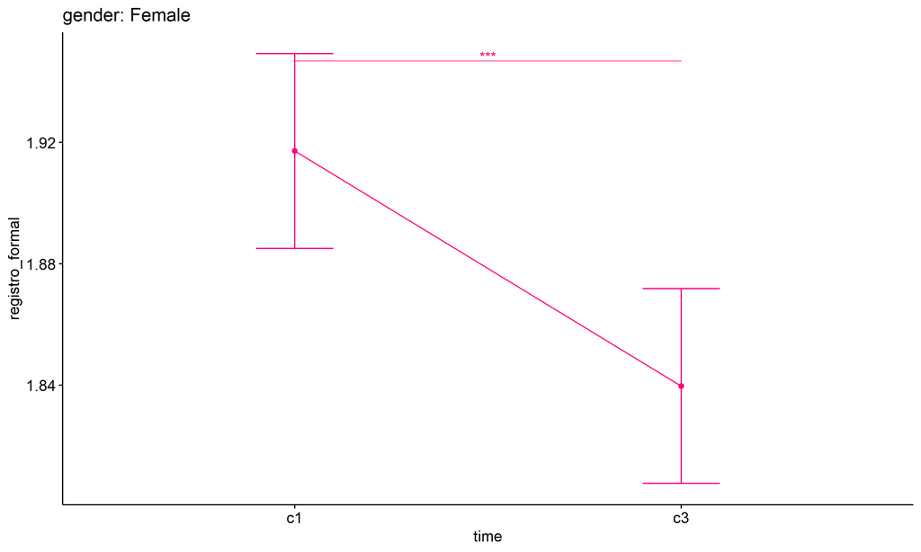

```r
emms.gg <- emms[which(emms$gender == "Female"),]
if (nrow(emms.gg) > 0)
  ggline(emms.gg, x = "time", y = "emmean", color = "#FF007F", ylab = "registro_formal") +
    geom_errorbar(aes(ymin = conf.low, ymax = conf.high),
                  width = 0.2, color = "#FF007F") +
    stat_pvalue_manual(
      add_xy_position(pwc[which(pwc$gender == "Female"),],
                      x = "time", fun = "mean_se"),
      hide.ns = T, color = "#FF007F", tip.length = F) +
    labs(title = "gender: Female")+
    theme(legend.text = element_blank())
```

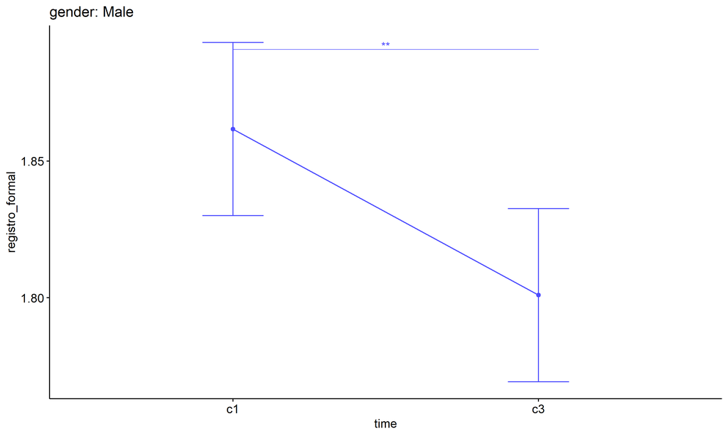

```r
emms.gg <- emms[which(emms$gender == "Male"),]
if (nrow(emms.gg) > 0)
  ggline(emms.gg, x = "time", y = "emmean", color = "#4D4DFF", ylab = "registro_formal") +
    geom_errorbar(aes(ymin = conf.low, ymax = conf.high),
                  width = 0.2, color = "#4D4DFF") +
    stat_pvalue_manual(
      add_xy_position(pwc[which(pwc$gender == "Male"),],
                      x = "time", fun = "mean_se"),
      hide.ns = T, color = "#4D4DFF", tip.length = F) +
    labs(title = "gender: Male")+
    theme(legend.text = element_blank())
```

## PairWise Computation after removing non.normal data

```r
if (length(non.ids) > 0)
  (pwc2 <- ldat2 %>% group_by(time) %>%
     emmeans_test(registro_formal ~ gender, detailed = T, p.adjust.method = "bonferroni"))
```

```r
if (length(non.ids) > 0)
  (emms2 <- get_emmeans(pwc2))
```

```r
if (length(non.ids) > 0) {
  pwc2 <- add_xy_position(pwc2, x = "time", fun = "mean_se", dodge = 0.25)
  pd2 <- position_dodge(width = 0.25)

  ggline(emms2, x = "time", y = "emmean", color = "gender",
         palette = c("#FF007F","#4D4DFF"),
         position = pd, ylab = "registro_formal") +
    geom_errorbar(aes(ymin = conf.low, ymax = conf.high, color = gender),
                position = pd, width = 0.2) +
    stat_pvalue_manual(pwc2, hide.ns = T, tip.length = F, linetype = 1)
}
```

```r
if (length(non.ids) > 0)
  (pwc2 <- ldat2 %>% group_by(gender) %>%
     emmeans_test(registro_formal ~ time, detailed = T, p.adjust.method = "bonferroni"))
```

```r
if (length(non.ids) > 0)
  (emms2 <- get_emmeans(pwc2))
```

```r
if (length(non.ids) > 0) {
  emms.gg <- emms2[which(emms2$gender == "Female"),]
  if (nrow(emms.gg) > 0)
    ggline(emms.gg, x = "time", y = "emmean", color = "#FF007F", ylab = "registro_formal") +
    geom_errorbar(aes(ymin = conf.low, ymax = conf.high),
                  width = 0.2, color = "#FF007F") +
    stat_pvalue_manual(
      add_xy_position(pwc[which(pwc$gender == "Female"),],
                      x = "time", fun = "mean_se"),
      hide.ns = T, color = "#FF007F", tip.length = F) +
    labs(title = "gender: Female") +
    theme(legend.text = element_blank())
}
```

```r
if (length(non.ids) > 0) {
  emms.gg <- emms2[which(emms2$gender == "Male"),]
  if (nrow(emms.gg) > 0)
    ggline(emms.gg, x = "time", y = "emmean", color = "#4D4DFF", ylab = "registro_formal") +
    geom_errorbar(aes(ymin = conf.low, ymax = conf.high),
                  width = 0.2, color = "#4D4DFF") +
    stat_pvalue_manual(
      add_xy_position(pwc[which(pwc$gender == "Male"),],
                      x = "time", fun = "mean_se"),
      hide.ns = T, color = "#4D4DFF", tip.length = F) +
    labs(title = "gender: Male") +
    theme(legend.text = element_blank())
}
```

# ANOVA: registro_formal ~ time*localizacao + Error(id/time)

## Data Preparation

```r
data <- edat[,c("aluno_id","localizacao","ciclo","registro_formal")]
data <- data[data$ciclo %in% c("Primeiro Ciclo","Terceiro Ciclo"),]
data$ciclo <- factor(data$ciclo, c("Primeiro Ciclo","Terceiro Ciclo"))
data <- unique(data)

wdat <- spread(data, ciclo, registro_formal)
wdat <- wdat[complete.cases(wdat),]
colnames(wdat) <- c("id","localizacao","c1","c3")

ldat <- gather(wdat, key = time, value = registro_formal, c1,c3) %>%
  convert_as_factor(id, time)
ldat <- remove_group_data(ldat, "registro_formal", c("time", "localizacao"), n.limit = 30)
ldat$localizacao <- factor(ldat$localizacao, sort(unique(ldat$localizacao)))
```

### Check assumptions: Identifying Outliers

```r
outliers <- identify_outliers(group_by(ldat, time, localizacao), registro_formal)
(outliers <- outliers[outliers$is.extreme == T,])
```

```
## # A tibble: 34 × 6
##    localizacao time  id                   registro_formal is.outlier is.extreme
##    <fct>       <fct> <fct>                          <dbl> <lgl>      <lgl>
##  1 Urbana      c1    8zkBFEUAFkixLZcY9EP0               4 TRUE       TRUE
##  2 Urbana      c1    baitWvlruSoQV9MUrIgr               4 TRUE       TRUE
##  3 Urbana      c1    cWE83pbQy4poly6i3xSL               4 TRUE       TRUE
##  4 Urbana      c1    eB5aBuW6Xqe2pUkHRfnL               4 TRUE       TRUE
##  5 Urbana      c1    htbyM16UJUtyqr6P6Jfi               4 TRUE       TRUE
##  6 Urbana      c1    IS6H8SGCc2Qi3Sc76Hdu               4 TRUE       TRUE
##  7 Urbana      c1    iyHsVjMJJRSYypImpewF               4 TRUE       TRUE
##  8 Urbana      c1    K7BVRqiiNsRjisKvt85x               4 TRUE       TRUE
##  9 Urbana      c1    KaCG3CroQpZookJ14Oed               4 TRUE       TRUE
## 10 Urbana      c1    kG5EWNlF7iFys7u9NU2S               4 TRUE       TRUE
## # ℹ 24 more rows
```

| localizacao | time | id | registro_formal | is.outlier | is.extreme |
| --- | --- | --- | --- | --- | --- |
| Urbana | c1 | 8zkBFEUAFkixLZcY9EP0 | 4 | TRUE | TRUE |
| Urbana | c1 | baitWvlruSoQV9MUrIgr | 4 | TRUE | TRUE |
| Urbana | c1 | cWE83pbQy4poly6i3xSL | 4 | TRUE | TRUE |
| Urbana | c1 | eB5aBuW6Xqe2pUkHRfnL | 4 | TRUE | TRUE |
| Urbana | c1 | htbyM16UJUtyqr6P6Jfi | 4 | TRUE | TRUE |
| Urbana | c1 | IS6H8SGCc2Qi3Sc76Hdu | 4 | TRUE | TRUE |
| Urbana | c1 | iyHsVjMJJRSYypImpewF | 4 | TRUE | TRUE |
| Urbana | c1 | K7BVRqiiNsRjisKvt85x | 4 | TRUE | TRUE |
| Urbana | c1 | KaCG3CroQpZookJ14Oed | 4 | TRUE | TRUE |
| Urbana | c1 | kG5EWNlF7iFys7u9NU2S | 4 | TRUE | TRUE |
| Urbana | c1 | KsNDea9pyWSqZNmzKPcL | 4 | TRUE | TRUE |
| Urbana | c1 | KVczxDz6q9HPFXqxmy1G | 4 | TRUE | TRUE |
| Urbana | c1 | KxutDWOwf7c7zs3WzsVK | 4 | TRUE | TRUE |
| Urbana | c1 | lcQkFKelmfF3AvUDkp2E | 4 | TRUE | TRUE |
| Urbana | c1 | NfGKElZsj63hOTrB2e5M | 4 | TRUE | TRUE |
| Urbana | c1 | nqxuyy3NvKzRwok1AiGQ | 4 | TRUE | TRUE |
| Urbana | c1 | NXvel6ktXlJ6LeTLisl6 | 4 | TRUE | TRUE |
| Urbana | c1 | oCdc6ouxkfn0i0Q5NmmU | 4 | TRUE | TRUE |
| Urbana | c1 | qapU5TnFRgKOIiu6Mhxr | 4 | TRUE | TRUE |
| Urbana | c1 | sIoy2GB8m7C2p6qtFBB4 | 4 | TRUE | TRUE |
| Urbana | c1 | SshX9BXtzAfFlsOTZAid | 4 | TRUE | TRUE |
| Urbana | c1 | tbaJOm2fecWIzyknkmjZ | 4 | TRUE | TRUE |
| Urbana | c1 | tmFRnwP1EI4qeDkRvZDt | 4 | TRUE | TRUE |
| Urbana | c1 | UqLUlHER7l3QQ8FNufkX | 4 | TRUE | TRUE |
| Urbana | c1 | VBdctSnsWQ6Xz1eKn53t | 4 | TRUE | TRUE |
| Urbana | c1 | wCRkCrxzSKzu3xtWPtn3 | 4 | TRUE | TRUE |
| Urbana | c1 | WliDxeLsUXTgNB5sq98e | 4 | TRUE | TRUE |
| Urbana | c1 | WzqnGmdKqtGjsbTzarNN | 4 | TRUE | TRUE |
| Urbana | c1 | XifeitosHzGsyw8Rt5o3 | 4 | TRUE | TRUE |
| Urbana | c1 | XqDnfcg1NBKmeeKWYgH6 | 4 | TRUE | TRUE |
| Urbana | c1 | z2QmSnbU36Vigu2L11Ma | 4 | TRUE | TRUE |
| Urbana | c1 | Z3wZBU0s09KRxFHiK8eK | 4 | TRUE | TRUE |
| Urbana | c1 | ZdunfmhB62wiMqQtoC6K | 4 | TRUE | TRUE |
| Urbana | c1 | ZQGZhiLTqE3hv9N29HCv | 4 | TRUE | TRUE |

### Check assumptions: Normality Test

```r
(normality.df <- normality.test.per.groups(ldat, "registro_formal", c("time", "localizacao")))
```

```
##               var        variable time localizacao    n  skewness     kurtosis
## 1 registro_formal registro_formal   c1       Rural  683 0.3202977 -0.442942579
## 2 registro_formal registro_formal   c1      Urbana 3314 0.5385338 -0.160310017
## 3 registro_formal registro_formal   c3       Rural  683 0.2770754 -0.680213336
## 4 registro_formal registro_formal   c3      Urbana 3314 0.6481270  0.008555855
##   symmetry statistic     method            p p.signif normality
## 1      YES  19.72797 D'Agostino 5.201470e-05      ***         -
## 2       NO 145.92276 D'Agostino 0.000000e+00     ****         -
## 3      YES  38.49087 D'Agostino 4.383424e-09     ****         -
## 4       NO 196.30928 D'Agostino 0.000000e+00     ****         -
```

| var | variable | time | localizacao | n | skewness | kurtosis | symmetry | statistic | method | p | p.signif | normality |
| --- | --- | --- | --- | --- | --- | --- | --- | --- | --- | --- | --- | --- |
| registro_formal | registro_formal | c1 | Rural | 683 | 0.320 | -0.443 | YES | 19.728 | D’Agostino | 0 | *** | - |
| registro_formal | registro_formal | c1 | Urbana | 3314 | 0.539 | -0.160 | NO | 145.923 | D’Agostino | 0 | **** | - |
| registro_formal | registro_formal | c3 | Rural | 683 | 0.277 | -0.680 | YES | 38.491 | D’Agostino | 0 | **** | - |
| registro_formal | registro_formal | c3 | Urbana | 3314 | 0.648 | 0.009 | NO | 196.309 | D’Agostino | 0 | **** | - |

```r
(non.ids <- unique(do.call(
  c, lapply(which(normality.df$normality == 'NO'), FUN = function(i) {
  idx = which(ldat$time == normality.df$time[i] &
                ldat$localizacao == normality.df$localizacao[i])
  getNonNormal(ldat$"registro_formal"[idx], ldat$id[idx])
}))))
```

```r
if (length(non.ids) > 0)
  ldat2 <- ldat[!ldat$id %in% non.ids,]
```

### Summary Statistics

```r
(sdat <- ldat %>% group_by(time, localizacao) %>%
   get_summary_stats(registro_formal, type = "mean_sd"))
```

```
## # A tibble: 4 × 6
##   localizacao time  variable            n  mean    sd
##   <fct>       <fct> <fct>           <dbl> <dbl> <dbl>
## 1 Rural       c1    registro_formal   683  2.02 0.695
## 2 Urbana      c1    registro_formal  3314  1.86 0.683
## 3 Rural       c3    registro_formal   683  2.04 0.789
## 4 Urbana      c3    registro_formal  3314  1.78 0.712
```

| localizacao | time | variable | n | mean | sd |
| --- | --- | --- | --- | --- | --- |
| Rural | c1 | registro_formal | 683 | 2.022 | 0.695 |
| Urbana | c1 | registro_formal | 3314 | 1.861 | 0.683 |
| Rural | c3 | registro_formal | 683 | 2.035 | 0.789 |
| Urbana | c3 | registro_formal | 3314 | 1.777 | 0.712 |

```r
if (length(non.ids) > 0)
  (sdat <- ldat2 %>% group_by(time, localizacao) %>%
      get_summary_stats(registro_formal, type = "mean_sd"))
```

| localizacao | time | variable | n | mean | sd |
| --- | --- | --- | --- | --- | --- |
| Rural | c1 | registro_formal | 683 | 2.022 | 0.695 |
| Urbana | c1 | registro_formal | 3314 | 1.861 | 0.683 |
| Rural | c3 | registro_formal | 683 | 2.035 | 0.789 |
| Urbana | c3 | registro_formal | 3314 | 1.777 | 0.712 |

## ANOVA Computation

```r
(res.aov <- anova_test(ldat, dv = registro_formal, wid = id, between = localizacao, within = time))
```

```
## ANOVA Table (type III tests)
##
##             Effect DFn  DFd      F        p p<.05      ges
## 1      localizacao   1 3995 91.043 2.37e-21     * 0.012000
## 2             time   1 3995  3.237 7.20e-02       0.000367
## 3 localizacao:time   1 3995  5.926 1.50e-02     * 0.000672
```

## ANOVA Computation after removing non.normal data

```r
if (length(non.ids) > 0)
  (res.aov2 <- anova_test(ldat2, dv = registro_formal, wid = id, between = localizacao , within = time))
```

## PairWise Computation

```r
(pwc <- ldat %>% group_by(time) %>%
   emmeans_test(registro_formal ~ localizacao, detailed = T, p.adjust.method = "bonferroni"))
```

```
## # A tibble: 2 × 15
##   time  term       .y.   group1 group2 null.value estimate     se    df conf.low
## * <fct> <chr>      <chr> <chr>  <chr>       <dbl>    <dbl>  <dbl> <dbl>    <dbl>
## 1 c1    localizac… regi… Rural  Urbana          0    0.161 0.0297  7990    0.102
## 2 c3    localizac… regi… Rural  Urbana          0    0.258 0.0297  7990    0.200
## # ℹ 5 more variables: conf.high <dbl>, statistic <dbl>, p <dbl>, p.adj <dbl>,
## #   p.adj.signif <chr>
```

| time | term | .y. | group1 | group2 | null.value | estimate | se | df | conf.low | conf.high | statistic | p | p.adj | p.adj.signif |
| --- | --- | --- | --- | --- | --- | --- | --- | --- | --- | --- | --- | --- | --- | --- |
| c1 | localizacao | registro_formal | Rural | Urbana | 0 | 0.161 | 0.03 | 7990 | 0.102 | 0.219 | 5.413 | 0 | 0 | **** |
| c3 | localizacao | registro_formal | Rural | Urbana | 0 | 0.258 | 0.03 | 7990 | 0.200 | 0.316 | 8.692 | 0 | 0 | **** |

```r
(emms <- get_emmeans(pwc))
```

```
## # A tibble: 4 × 8
##   time  localizacao emmean     se    df conf.low conf.high method
##   <fct> <fct>        <dbl>  <dbl> <dbl>    <dbl>     <dbl> <chr>
## 1 c1    Rural         2.02 0.0270  7990     1.97      2.07 Emmeans test
## 2 c1    Urbana        1.86 0.0123  7990     1.84      1.89 Emmeans test
## 3 c3    Rural         2.03 0.0270  7990     1.98      2.09 Emmeans test
## 4 c3    Urbana        1.78 0.0123  7990     1.75      1.80 Emmeans test
```

| time | localizacao | emmean | se | df | conf.low | conf.high | method |
| --- | --- | --- | --- | --- | --- | --- | --- |
| c1 | Rural | 2.022 | 0.027 | 7990 | 1.969 | 2.075 | Emmeans test |
| c1 | Urbana | 1.861 | 0.012 | 7990 | 1.837 | 1.885 | Emmeans test |
| c3 | Rural | 2.035 | 0.027 | 7990 | 1.982 | 2.088 | Emmeans test |
| c3 | Urbana | 1.777 | 0.012 | 7990 | 1.753 | 1.801 | Emmeans test |

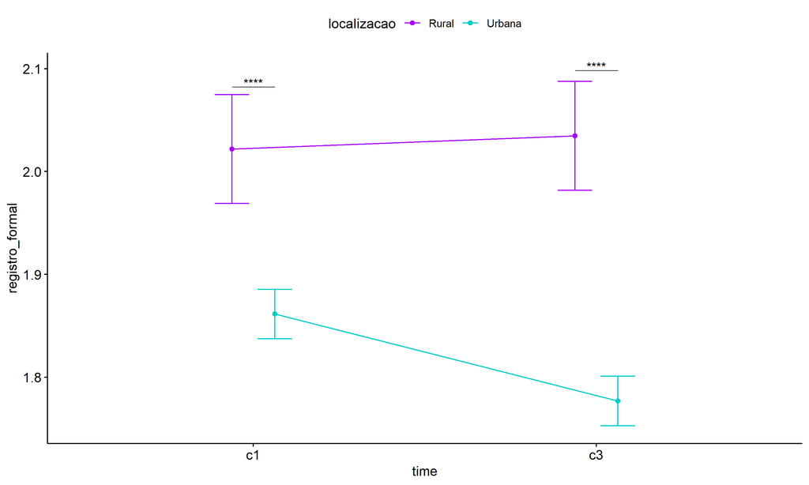

```r
pwc <- add_xy_position(pwc, x = "time", fun = "mean_se", dodge = 0.25)
pd <- position_dodge(width = 0.25)
ggline(emms, x = "time", y = "emmean", color = "localizacao",
       palette = c("#AA00FF","#00CCCC"),
       position = pd, ylab = "registro_formal") +
  geom_errorbar(aes(ymin = conf.low, ymax = conf.high, color = localizacao),
                position = pd, width = 0.2) +
  stat_pvalue_manual(pwc, hide.ns = T, tip.length = F, linetype = 1)
```

```r
(pwc <- ldat %>% group_by(localizacao) %>%
    emmeans_test(registro_formal ~ time, detailed = T, p.adjust.method = "bonferroni"))
```

```
## # A tibble: 2 × 15
##   localizacao term  .y.           group1 group2 null.value estimate     se    df
## * <fct>       <chr> <chr>         <chr>  <chr>       <dbl>    <dbl>  <dbl> <dbl>
## 1 Rural       time  registro_for… c1     c3              0  -0.0127 0.0382  7990
## 2 Urbana      time  registro_for… c1     c3              0   0.0846 0.0173  7990
## # ℹ 6 more variables: conf.low <dbl>, conf.high <dbl>, statistic <dbl>,
## #   p <dbl>, p.adj <dbl>, p.adj.signif <chr>
```

| localizacao | term | .y. | group1 | group2 | null.value | estimate | se | df | conf.low | conf.high | statistic | p | p.adj | p.adj.signif |
| --- | --- | --- | --- | --- | --- | --- | --- | --- | --- | --- | --- | --- | --- | --- |
| Rural | time | registro_formal | c1 | c3 | 0 | -0.013 | 0.038 | 7990 | -0.088 | 0.062 | -0.332 | 0.74 | 0.74 | ns |
| Urbana | time | registro_formal | c1 | c3 | 0 | 0.085 | 0.017 | 7990 | 0.051 | 0.119 | 4.877 | 0.00 | 0.00 | **** |

```r
(emms <- get_emmeans(pwc))
```

```
## # A tibble: 4 × 8
##   localizacao time  emmean     se    df conf.low conf.high method
##   <fct>       <fct>  <dbl>  <dbl> <dbl>    <dbl>     <dbl> <chr>
## 1 Rural       c1      2.02 0.0270  7990     1.97      2.07 Emmeans test
## 2 Rural       c3      2.03 0.0270  7990     1.98      2.09 Emmeans test
## 3 Urbana      c1      1.86 0.0123  7990     1.84      1.89 Emmeans test
## 4 Urbana      c3      1.78 0.0123  7990     1.75      1.80 Emmeans test
```

| localizacao | time | emmean | se | df | conf.low | conf.high | method |
| --- | --- | --- | --- | --- | --- | --- | --- |
| Rural | c1 | 2.022 | 0.027 | 7990 | 1.969 | 2.075 | Emmeans test |
| Rural | c3 | 2.035 | 0.027 | 7990 | 1.982 | 2.088 | Emmeans test |
| Urbana | c1 | 1.861 | 0.012 | 7990 | 1.837 | 1.885 | Emmeans test |
| Urbana | c3 | 1.777 | 0.012 | 7990 | 1.753 | 1.801 | Emmeans test |

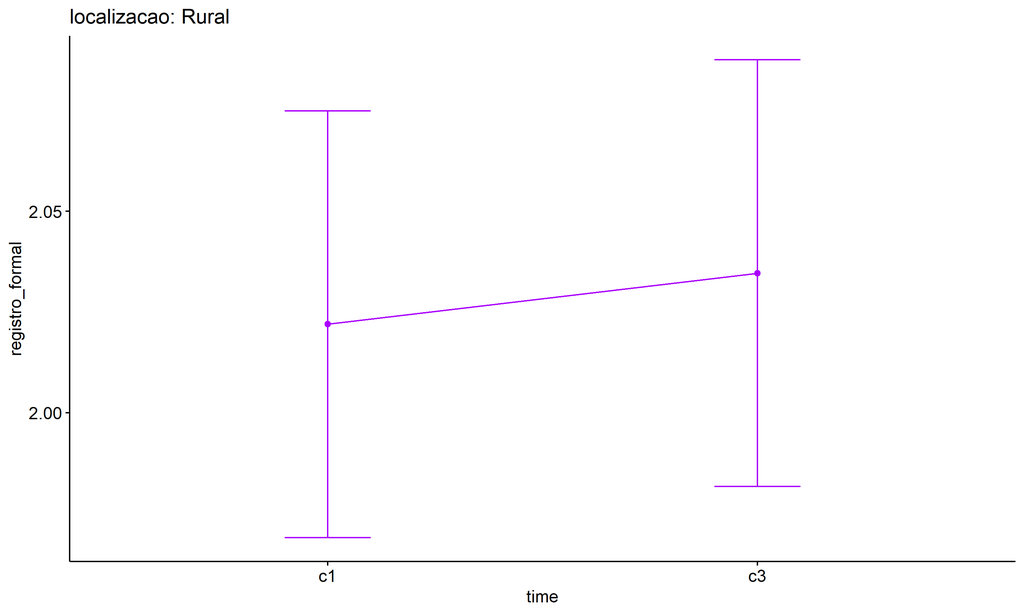

```r
emms.gg <- emms[which(emms$localizacao == "Rural"),]
if (nrow(emms.gg) > 0)
  ggline(emms.gg, x = "time", y = "emmean", color = "#AA00FF", ylab = "registro_formal") +
    geom_errorbar(aes(ymin = conf.low, ymax = conf.high),
                  width = 0.2, color = "#AA00FF") +
    stat_pvalue_manual(
      add_xy_position(pwc[which(pwc$localizacao == "Rural"),],
                      x = "time", fun = "mean_se"),
      hide.ns = T, color = "#AA00FF", tip.length = F) +
    labs(title = "localizacao: Rural")+
    theme(legend.text = element_blank())
```

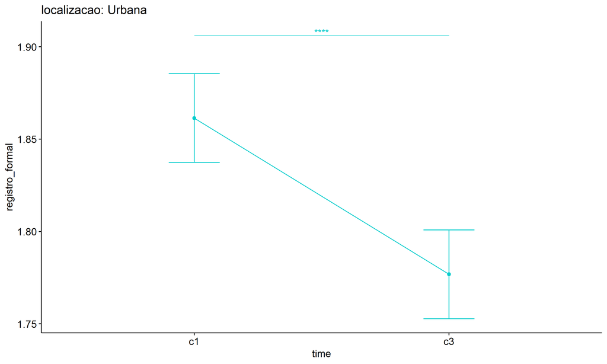

```r
emms.gg <- emms[which(emms$localizacao == "Urbana"),]
if (nrow(emms.gg) > 0)
  ggline(emms.gg, x = "time", y = "emmean", color = "#00CCCC", ylab = "registro_formal") +
    geom_errorbar(aes(ymin = conf.low, ymax = conf.high),
                  width = 0.2, color = "#00CCCC") +
    stat_pvalue_manual(
      add_xy_position(pwc[which(pwc$localizacao == "Urbana"),],
                      x = "time", fun = "mean_se"),
      hide.ns = T, color = "#00CCCC", tip.length = F) +
    labs(title = "localizacao: Urbana")+
    theme(legend.text = element_blank())
```

## PairWise Computation after removing non.normal data

```r
if (length(non.ids) > 0)
  (pwc2 <- ldat2 %>% group_by(time) %>%
     emmeans_test(registro_formal ~ localizacao, detailed = T, p.adjust.method = "bonferroni"))
```

```r
if (length(non.ids) > 0)
  (emms2 <- get_emmeans(pwc2))
```

```r
if (length(non.ids) > 0) {
  pwc2 <- add_xy_position(pwc2, x = "time", fun = "mean_se", dodge = 0.25)
  pd2 <- position_dodge(width = 0.25)

  ggline(emms2, x = "time", y = "emmean", color = "localizacao",
         palette = c("#AA00FF","#00CCCC"),
         position = pd, ylab = "registro_formal") +
    geom_errorbar(aes(ymin = conf.low, ymax = conf.high, color = localizacao),
                position = pd, width = 0.2) +
    stat_pvalue_manual(pwc2, hide.ns = T, tip.length = F, linetype = 1)
}
```

```r
if (length(non.ids) > 0)
  (pwc2 <- ldat2 %>% group_by(localizacao) %>%
     emmeans_test(registro_formal ~ time, detailed = T, p.adjust.method = "bonferroni"))
```

```r
if (length(non.ids) > 0)
  (emms2 <- get_emmeans(pwc2))
```

```r
if (length(non.ids) > 0) {
  emms.gg <- emms2[which(emms2$localizacao == "Rural"),]
  if (nrow(emms.gg) > 0)
    ggline(emms.gg, x = "time", y = "emmean", color = "#AA00FF", ylab = "registro_formal") +
    geom_errorbar(aes(ymin = conf.low, ymax = conf.high),
                  width = 0.2, color = "#AA00FF") +
    stat_pvalue_manual(
      add_xy_position(pwc[which(pwc$localizacao == "Rural"),],
                      x = "time", fun = "mean_se"),
      hide.ns = T, color = "#AA00FF", tip.length = F) +
    labs(title = "localizacao: Rural") +
    theme(legend.text = element_blank())
}
```

```r
if (length(non.ids) > 0) {
  emms.gg <- emms2[which(emms2$localizacao == "Urbana"),]
  if (nrow(emms.gg) > 0)
    ggline(emms.gg, x = "time", y = "emmean", color = "#00CCCC", ylab = "registro_formal") +
    geom_errorbar(aes(ymin = conf.low, ymax = conf.high),
                  width = 0.2, color = "#00CCCC") +
    stat_pvalue_manual(
      add_xy_position(pwc[which(pwc$localizacao == "Urbana"),],
                      x = "time", fun = "mean_se"),
      hide.ns = T, color = "#00CCCC", tip.length = F) +
    labs(title = "localizacao: Urbana") +
    theme(legend.text = element_blank())
}
```

# ANOVA: registro_formal ~ time*regiao + Error(id/time)

## Data Preparation

```r
data <- edat[,c("aluno_id","regiao","ciclo","registro_formal")]
data <- data[data$ciclo %in% c("Primeiro Ciclo","Terceiro Ciclo"),]
data$ciclo <- factor(data$ciclo, c("Primeiro Ciclo","Terceiro Ciclo"))
data <- unique(data)

wdat <- spread(data, ciclo, registro_formal)
wdat <- wdat[complete.cases(wdat),]
colnames(wdat) <- c("id","regiao","c1","c3")

ldat <- gather(wdat, key = time, value = registro_formal, c1,c3) %>%
  convert_as_factor(id, time)
ldat <- remove_group_data(ldat, "registro_formal", c("time", "regiao"), n.limit = 30)
ldat$regiao <- factor(ldat$regiao, sort(unique(ldat$regiao)))
```

### Check assumptions: Identifying Outliers

```r
outliers <- identify_outliers(group_by(ldat, time, regiao), registro_formal)
(outliers <- outliers[outliers$is.extreme == T,])
```

```
## # A tibble: 1 × 6
##   regiao       time  id                   registro_formal is.outlier is.extreme
##   <fct>        <fct> <fct>                          <dbl> <lgl>      <lgl>
## 1 Centro-Oeste c1    qapU5TnFRgKOIiu6Mhxr               4 TRUE       TRUE
```

| regiao | time | id | registro_formal | is.outlier | is.extreme |
| --- | --- | --- | --- | --- | --- |
| Centro-Oeste | c1 | qapU5TnFRgKOIiu6Mhxr | 4 | TRUE | TRUE |

### Check assumptions: Normality Test

```r
(normality.df <- normality.test.per.groups(ldat, "registro_formal", c("time", "regiao")))
```

```
##                var        variable time       regiao    n  skewness    kurtosis
## 1  registro_formal registro_formal   c1 Centro-Oeste  288 0.5308080  0.03759953
## 2  registro_formal registro_formal   c1     Nordeste 1287 0.4172834 -0.32743691
## 3  registro_formal registro_formal   c1        Norte  249 0.1653443 -0.71131027
## 4  registro_formal registro_formal   c1      Sudeste 2097 0.5797407 -0.10452438
## 5  registro_formal registro_formal   c1          Sul   76 0.2465728 -0.32897887
## 6  registro_formal registro_formal   c3 Centro-Oeste  288 0.3660385 -0.12276607
## 7  registro_formal registro_formal   c3     Nordeste 1287 0.5078902 -0.43689570
## 8  registro_formal registro_formal   c3        Norte  249 0.6541512  0.15033763
## 9  registro_formal registro_formal   c3      Sudeste 2097 0.6279601 -0.11027479
## 10 registro_formal registro_formal   c3          Sul   76 0.6161480  0.14610240
##    symmetry  statistic     method            p p.signif normality
## 1        NO  12.940306 D'Agostino 1.548989e-03        *         -
## 2       YES  42.572966 D'Agostino 5.693743e-10     ****         -
## 3       YES  11.990686 D'Agostino 2.490323e-03        *         -
## 4        NO 103.609194 D'Agostino 0.000000e+00     ****         -
## 5       YES   0.957147 D'Agostino 6.196667e-01       ns       YES
## 6       YES   6.465030 D'Agostino 3.945813e-02       ns         -
## 7        NO  66.164647 D'Agostino 4.329870e-15     ****         -
## 8        NO  16.684871 D'Agostino 2.381916e-04       **         -
## 9        NO 119.036393 D'Agostino 0.000000e+00     ****         -
## 10       NO   5.734172 D'Agostino 5.686440e-02       ns       YES
```

| var | variable | time | regiao | n | skewness | kurtosis | symmetry | statistic | method | p | p.signif | normality |
| --- | --- | --- | --- | --- | --- | --- | --- | --- | --- | --- | --- | --- |
| registro_formal | registro_formal | c1 | Centro-Oeste | 288 | 0.531 | 0.038 | NO | 12.940 | D’Agostino | 0.002 | * | - |
| registro_formal | registro_formal | c1 | Nordeste | 1287 | 0.417 | -0.327 | YES | 42.573 | D’Agostino | 0.000 | **** | - |
| registro_formal | registro_formal | c1 | Norte | 249 | 0.165 | -0.711 | YES | 11.991 | D’Agostino | 0.002 | * | - |
| registro_formal | registro_formal | c1 | Sudeste | 2097 | 0.580 | -0.105 | NO | 103.609 | D’Agostino | 0.000 | **** | - |
| registro_formal | registro_formal | c1 | Sul | 76 | 0.247 | -0.329 | YES | 0.957 | D’Agostino | 0.620 | ns | YES |
| registro_formal | registro_formal | c3 | Centro-Oeste | 288 | 0.366 | -0.123 | YES | 6.465 | D’Agostino | 0.039 | ns | - |
| registro_formal | registro_formal | c3 | Nordeste | 1287 | 0.508 | -0.437 | NO | 66.165 | D’Agostino | 0.000 | **** | - |
| registro_formal | registro_formal | c3 | Norte | 249 | 0.654 | 0.150 | NO | 16.685 | D’Agostino | 0.000 | ** | - |
| registro_formal | registro_formal | c3 | Sudeste | 2097 | 0.628 | -0.110 | NO | 119.036 | D’Agostino | 0.000 | **** | - |
| registro_formal | registro_formal | c3 | Sul | 76 | 0.616 | 0.146 | NO | 5.734 | D’Agostino | 0.057 | ns | YES |

```r
(non.ids <- unique(do.call(
  c, lapply(which(normality.df$normality == 'NO'), FUN = function(i) {
  idx = which(ldat$time == normality.df$time[i] &
                ldat$regiao == normality.df$regiao[i])
  getNonNormal(ldat$"registro_formal"[idx], ldat$id[idx])
}))))
```

```r
if (length(non.ids) > 0)
  ldat2 <- ldat[!ldat$id %in% non.ids,]
```

### Summary Statistics

```r
(sdat <- ldat %>% group_by(time, regiao) %>%
   get_summary_stats(registro_formal, type = "mean_sd"))
```

```
## # A tibble: 10 × 6
##    regiao       time  variable            n  mean    sd
##    <fct>        <fct> <fct>           <dbl> <dbl> <dbl>
##  1 Centro-Oeste c1    registro_formal   288  1.81 0.6
##  2 Nordeste     c1    registro_formal  1287  1.97 0.707
##  3 Norte        c1    registro_formal   249  2.04 0.724
##  4 Sudeste      c1    registro_formal  2097  1.82 0.672
##  5 Sul          c1    registro_formal    76  2.16 0.718
##  6 Centro-Oeste c3    registro_formal   288  1.78 0.604
##  7 Nordeste     c3    registro_formal  1287  1.88 0.768
##  8 Norte        c3    registro_formal   249  1.91 0.76
##  9 Sudeste      c3    registro_formal  2097  1.78 0.719
## 10 Sul          c3    registro_formal    76  1.86 0.743
```

| regiao | time | variable | n | mean | sd |
| --- | --- | --- | --- | --- | --- |
| Centro-Oeste | c1 | registro_formal | 288 | 1.812 | 0.600 |
| Nordeste | c1 | registro_formal | 1287 | 1.967 | 0.707 |
| Norte | c1 | registro_formal | 249 | 2.039 | 0.724 |
| Sudeste | c1 | registro_formal | 2097 | 1.823 | 0.672 |
| Sul | c1 | registro_formal | 76 | 2.164 | 0.718 |
| Centro-Oeste | c3 | registro_formal | 288 | 1.783 | 0.604 |
| Nordeste | c3 | registro_formal | 1287 | 1.879 | 0.768 |
| Norte | c3 | registro_formal | 249 | 1.910 | 0.760 |
| Sudeste | c3 | registro_formal | 2097 | 1.778 | 0.719 |
| Sul | c3 | registro_formal | 76 | 1.855 | 0.743 |

```r
if (length(non.ids) > 0)
  (sdat <- ldat2 %>% group_by(time, regiao) %>%
      get_summary_stats(registro_formal, type = "mean_sd"))
```

| regiao | time | variable | n | mean | sd |
| --- | --- | --- | --- | --- | --- |
| Centro-Oeste | c1 | registro_formal | 288 | 1.812 | 0.600 |
| Nordeste | c1 | registro_formal | 1287 | 1.967 | 0.707 |
| Norte | c1 | registro_formal | 249 | 2.039 | 0.724 |
| Sudeste | c1 | registro_formal | 2097 | 1.823 | 0.672 |
| Sul | c1 | registro_formal | 76 | 2.164 | 0.718 |
| Centro-Oeste | c3 | registro_formal | 288 | 1.783 | 0.604 |
| Nordeste | c3 | registro_formal | 1287 | 1.879 | 0.768 |
| Norte | c3 | registro_formal | 249 | 1.910 | 0.760 |
| Sudeste | c3 | registro_formal | 2097 | 1.778 | 0.719 |
| Sul | c3 | registro_formal | 76 | 1.855 | 0.743 |

## ANOVA Computation

```r
(res.aov <- anova_test(ldat, dv = registro_formal, wid = id, between = regiao, within = time))
```

```
## ANOVA Table (type III tests)
##
##        Effect DFn  DFd      F        p p<.05      ges
## 1      regiao   4 3992 16.858 1.03e-13     * 0.009000
## 2        time   1 3992 18.219 2.02e-05     * 0.002000
## 3 regiao:time   4 3992  2.052 8.40e-02       0.000929
```

## ANOVA Computation after removing non.normal data

```r
if (length(non.ids) > 0)
  (res.aov2 <- anova_test(ldat2, dv = registro_formal, wid = id, between = regiao , within = time))
```

## PairWise Computation

```r
(pwc <- ldat %>% group_by(time) %>%
   emmeans_test(registro_formal ~ regiao, detailed = T, p.adjust.method = "bonferroni"))
```

| time | term | .y. | group1 | group2 | null.value | estimate | se | df | conf.low | conf.high | statistic | p | p.adj | p.adj.signif |
| --- | --- | --- | --- | --- | --- | --- | --- | --- | --- | --- | --- | --- | --- | --- |
| c1 | regiao | registro_formal | Centro | Oeste | 0 | -0.155 | 0.046 | 7984 | -0.245 | -0.065 | -3.360 | 0.001 | 0.008 | ** |
| c1 | regiao | registro_formal | Centro | Oeste | 0 | -0.227 | 0.061 | 7984 | -0.347 | -0.107 | -3.704 | 0.000 | 0.002 | ** |
| c1 | regiao | registro_formal | Centro | Oeste | 0 | -0.011 | 0.044 | 7984 | -0.098 | 0.076 | -0.243 | 0.808 | 1.000 | ns |
| c1 | regiao | registro_formal | Centro | Oeste | 0 | -0.352 | 0.091 | 7984 | -0.531 | -0.173 | -3.860 | 0.000 | 0.001 | ** |
| c1 | regiao | registro_formal | Nordeste | Norte | 0 | -0.072 | 0.049 | 7984 | -0.168 | 0.024 | -1.467 | 0.143 | 1.000 | ns |
| c1 | regiao | registro_formal | Nordeste | Sudeste | 0 | 0.144 | 0.025 | 7984 | 0.095 | 0.193 | 5.753 | 0.000 | 0.000 | **** |
| c1 | regiao | registro_formal | Nordeste | Sul | 0 | -0.197 | 0.083 | 7984 | -0.361 | -0.033 | -2.362 | 0.018 | 0.182 | ns |
| c1 | regiao | registro_formal | Norte | Sudeste | 0 | 0.216 | 0.047 | 7984 | 0.123 | 0.309 | 4.554 | 0.000 | 0.000 | **** |
| c1 | regiao | registro_formal | Norte | Sul | 0 | -0.125 | 0.093 | 7984 | -0.307 | 0.056 | -1.352 | 0.176 | 1.000 | ns |
| c1 | regiao | registro_formal | Sudeste | Sul | 0 | -0.341 | 0.083 | 7984 | -0.503 | -0.179 | -4.132 | 0.000 | 0.000 | *** |
| c3 | regiao | registro_formal | Centro | Oeste | 0 | -0.096 | 0.046 | 7984 | -0.187 | -0.006 | -2.087 | 0.037 | 0.369 | ns |
| c3 | regiao | registro_formal | Centro | Oeste | 0 | -0.127 | 0.061 | 7984 | -0.247 | -0.007 | -2.081 | 0.037 | 0.375 | ns |
| c3 | regiao | registro_formal | Centro | Oeste | 0 | 0.004 | 0.044 | 7984 | -0.083 | 0.092 | 0.101 | 0.919 | 1.000 | ns |
| c3 | regiao | registro_formal | Centro | Oeste | 0 | -0.072 | 0.091 | 7984 | -0.251 | 0.106 | -0.793 | 0.428 | 1.000 | ns |
| c3 | regiao | registro_formal | Nordeste | Norte | 0 | -0.031 | 0.049 | 7984 | -0.127 | 0.065 | -0.636 | 0.525 | 1.000 | ns |
| c3 | regiao | registro_formal | Nordeste | Sudeste | 0 | 0.101 | 0.025 | 7984 | 0.052 | 0.150 | 4.021 | 0.000 | 0.001 | *** |
| c3 | regiao | registro_formal | Nordeste | Sul | 0 | 0.024 | 0.083 | 7984 | -0.140 | 0.188 | 0.287 | 0.774 | 1.000 | ns |
| c3 | regiao | registro_formal | Norte | Sudeste | 0 | 0.132 | 0.047 | 7984 | 0.039 | 0.225 | 2.781 | 0.005 | 0.054 | ns |
| c3 | regiao | registro_formal | Norte | Sul | 0 | 0.055 | 0.093 | 7984 | -0.127 | 0.237 | 0.594 | 0.552 | 1.000 | ns |
| c3 | regiao | registro_formal | Sudeste | Sul | 0 | -0.077 | 0.083 | 7984 | -0.239 | 0.085 | -0.930 | 0.352 | 1.000 | ns |

```r
(emms <- get_emmeans(pwc))
```

```
## # A tibble: 10 × 8
##    time  regiao       emmean     se    df conf.low conf.high method
##    <fct> <fct>         <dbl>  <dbl> <dbl>    <dbl>     <dbl> <chr>
##  1 c1    Centro-Oeste   1.81 0.0417  7984     1.73      1.89 Emmeans test
##  2 c1    Nordeste       1.97 0.0197  7984     1.93      2.01 Emmeans test
##  3 c1    Norte          2.04 0.0448  7984     1.95      2.13 Emmeans test
##  4 c1    Sudeste        1.82 0.0154  7984     1.79      1.85 Emmeans test
##  5 c1    Sul            2.16 0.0811  7984     2.01      2.32 Emmeans test
##  6 c3    Centro-Oeste   1.78 0.0417  7984     1.70      1.86 Emmeans test
##  7 c3    Nordeste       1.88 0.0197  7984     1.84      1.92 Emmeans test
##  8 c3    Norte          1.91 0.0448  7984     1.82      2.00 Emmeans test
##  9 c3    Sudeste        1.78 0.0154  7984     1.75      1.81 Emmeans test
## 10 c3    Sul            1.86 0.0811  7984     1.70      2.01 Emmeans test
```

| time | regiao | emmean | se | df | conf.low | conf.high | method |
| --- | --- | --- | --- | --- | --- | --- | --- |
| c1 | Centro-Oeste | 1.813 | 0.042 | 7984 | 1.731 | 1.894 | Emmeans test |
| c1 | Nordeste | 1.967 | 0.020 | 7984 | 1.929 | 2.006 | Emmeans test |
| c1 | Norte | 2.039 | 0.045 | 7984 | 1.951 | 2.127 | Emmeans test |
| c1 | Sudeste | 1.823 | 0.015 | 7984 | 1.793 | 1.854 | Emmeans test |
| c1 | Sul | 2.164 | 0.081 | 7984 | 2.005 | 2.323 | Emmeans test |
| c3 | Centro-Oeste | 1.783 | 0.042 | 7984 | 1.701 | 1.865 | Emmeans test |
| c3 | Nordeste | 1.879 | 0.020 | 7984 | 1.841 | 1.918 | Emmeans test |
| c3 | Norte | 1.910 | 0.045 | 7984 | 1.822 | 1.998 | Emmeans test |
| c3 | Sudeste | 1.778 | 0.015 | 7984 | 1.748 | 1.809 | Emmeans test |
| c3 | Sul | 1.855 | 0.081 | 7984 | 1.696 | 2.014 | Emmeans test |

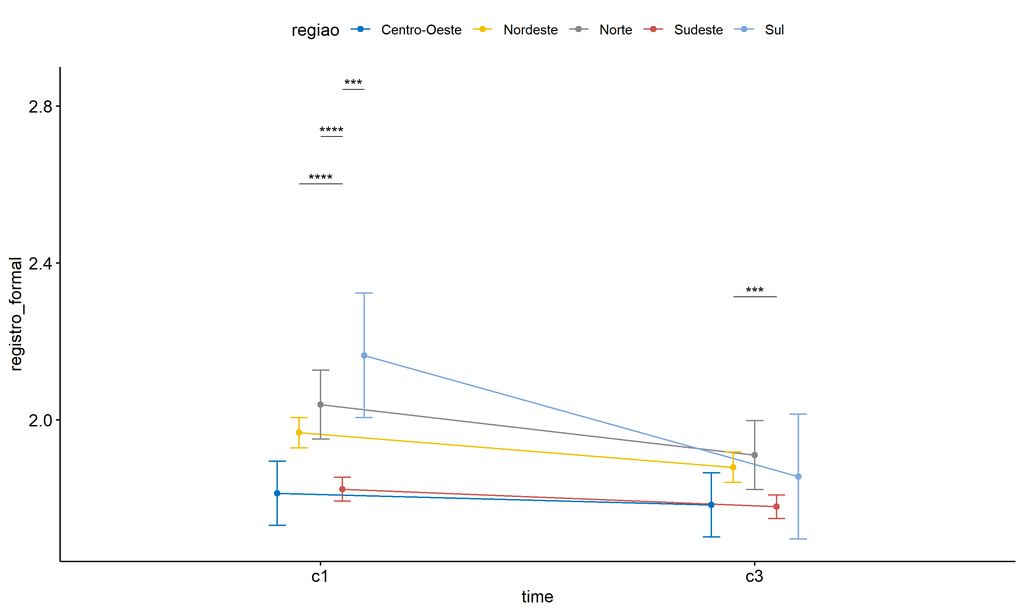

```r
pwc <- add_xy_position(pwc, x = "time", fun = "mean_se", dodge = 0.25)
pd <- position_dodge(width = 0.25)
ggline(emms, x = "time", y = "emmean", color = "regiao",
       palette = c("#0073C2FF","#EFC000FF","#868686FF","#CD534CFF","#7AA6DCFF"),
       position = pd, ylab = "registro_formal") +
  geom_errorbar(aes(ymin = conf.low, ymax = conf.high, color = regiao),
                position = pd, width = 0.2) +
  stat_pvalue_manual(pwc, hide.ns = T, tip.length = F, linetype = 1)
```

```r
(pwc <- ldat %>% group_by(regiao) %>%
    emmeans_test(registro_formal ~ time, detailed = T, p.adjust.method = "bonferroni"))
```

```
## # A tibble: 5 × 15
##   regiao     term  .y.   group1 group2 null.value estimate     se    df conf.low
## * <fct>      <chr> <chr> <chr>  <chr>       <dbl>    <dbl>  <dbl> <dbl>    <dbl>
## 1 Centro-Oe… time  regi… c1     c3              0   0.0295 0.0589  7984 -0.0860
## 2 Nordeste   time  regi… c1     c3              0   0.0882 0.0279  7984  0.0336
## 3 Norte      time  regi… c1     c3              0   0.129  0.0634  7984  0.00463
## 4 Sudeste    time  regi… c1     c3              0   0.0448 0.0218  7984  0.00202
## 5 Sul        time  regi… c1     c3              0   0.309  0.115   7984  0.0844
## # ℹ 5 more variables: conf.high <dbl>, statistic <dbl>, p <dbl>, p.adj <dbl>,
## #   p.adj.signif <chr>
```

| regiao | term | .y. | group1 | group2 | null.value | estimate | se | df | conf.low | conf.high | statistic | p | p.adj | p.adj.signif |
| --- | --- | --- | --- | --- | --- | --- | --- | --- | --- | --- | --- | --- | --- | --- |
| Centro-Oeste | time | registro_formal | c1 | c3 | 0 | 0.030 | 0.059 | 7984 | -0.086 | 0.145 | 0.501 | 0.616 | 0.616 | ns |
| Nordeste | time | registro_formal | c1 | c3 | 0 | 0.088 | 0.028 | 7984 | 0.034 | 0.143 | 3.164 | 0.002 | 0.002 | ** |
| Norte | time | registro_formal | c1 | c3 | 0 | 0.129 | 0.063 | 7984 | 0.005 | 0.253 | 2.033 | 0.042 | 0.042 | * |
| Sudeste | time | registro_formal | c1 | c3 | 0 | 0.045 | 0.022 | 7984 | 0.002 | 0.088 | 2.053 | 0.040 | 0.040 | * |
| Sul | time | registro_formal | c1 | c3 | 0 | 0.309 | 0.115 | 7984 | 0.084 | 0.534 | 2.696 | 0.007 | 0.007 | ** |

```r
(emms <- get_emmeans(pwc))
```

```
## # A tibble: 10 × 8
##    regiao       time  emmean     se    df conf.low conf.high method
##    <fct>        <fct>  <dbl>  <dbl> <dbl>    <dbl>     <dbl> <chr>
##  1 Centro-Oeste c1      1.81 0.0417  7984     1.73      1.89 Emmeans test
##  2 Centro-Oeste c3      1.78 0.0417  7984     1.70      1.86 Emmeans test
##  3 Nordeste     c1      1.97 0.0197  7984     1.93      2.01 Emmeans test
##  4 Nordeste     c3      1.88 0.0197  7984     1.84      1.92 Emmeans test
##  5 Norte        c1      2.04 0.0448  7984     1.95      2.13 Emmeans test
##  6 Norte        c3      1.91 0.0448  7984     1.82      2.00 Emmeans test
##  7 Sudeste      c1      1.82 0.0154  7984     1.79      1.85 Emmeans test
##  8 Sudeste      c3      1.78 0.0154  7984     1.75      1.81 Emmeans test
##  9 Sul          c1      2.16 0.0811  7984     2.01      2.32 Emmeans test
## 10 Sul          c3      1.86 0.0811  7984     1.70      2.01 Emmeans test
```

| regiao | time | emmean | se | df | conf.low | conf.high | method |
| --- | --- | --- | --- | --- | --- | --- | --- |
| Centro-Oeste | c1 | 1.813 | 0.042 | 7984 | 1.731 | 1.894 | Emmeans test |
| Centro-Oeste | c3 | 1.783 | 0.042 | 7984 | 1.701 | 1.865 | Emmeans test |
| Nordeste | c1 | 1.967 | 0.020 | 7984 | 1.929 | 2.006 | Emmeans test |
| Nordeste | c3 | 1.879 | 0.020 | 7984 | 1.841 | 1.918 | Emmeans test |
| Norte | c1 | 2.039 | 0.045 | 7984 | 1.951 | 2.127 | Emmeans test |
| Norte | c3 | 1.910 | 0.045 | 7984 | 1.822 | 1.998 | Emmeans test |
| Sudeste | c1 | 1.823 | 0.015 | 7984 | 1.793 | 1.854 | Emmeans test |
| Sudeste | c3 | 1.778 | 0.015 | 7984 | 1.748 | 1.809 | Emmeans test |
| Sul | c1 | 2.164 | 0.081 | 7984 | 2.005 | 2.323 | Emmeans test |
| Sul | c3 | 1.855 | 0.081 | 7984 | 1.696 | 2.014 | Emmeans test |

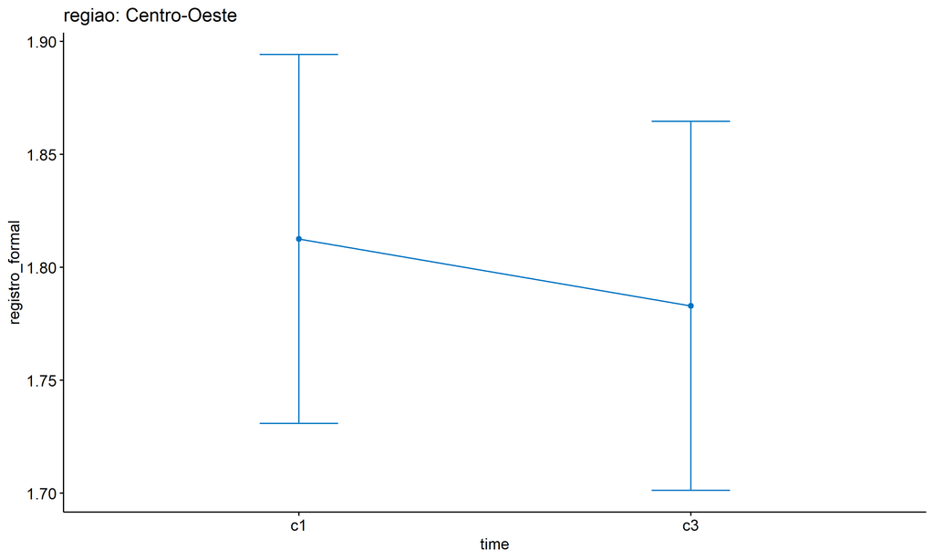

```r
emms.gg <- emms[which(emms$regiao == "Centro-Oeste"),]
if (nrow(emms.gg) > 0)
  ggline(emms.gg, x = "time", y = "emmean", color = "#0073C2FF", ylab = "registro_formal") +
    geom_errorbar(aes(ymin = conf.low, ymax = conf.high),
                  width = 0.2, color = "#0073C2FF") +
    stat_pvalue_manual(
      add_xy_position(pwc[which(pwc$regiao == "Centro-Oeste"),],
                      x = "time", fun = "mean_se"),
      hide.ns = T, color = "#0073C2FF", tip.length = F) +
    labs(title = "regiao: Centro-Oeste")+
    theme(legend.text = element_blank())
```

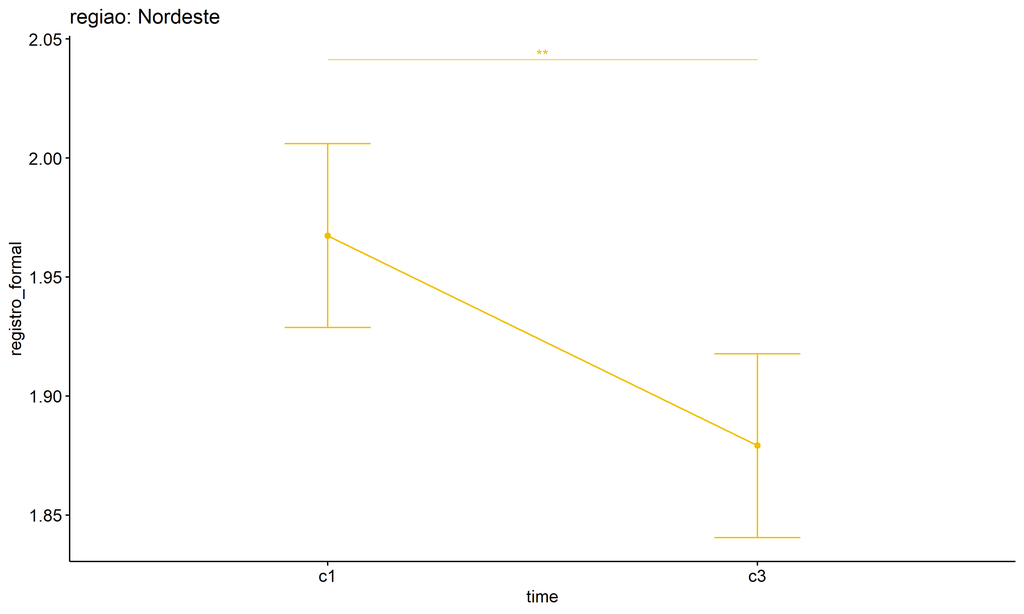

```r
emms.gg <- emms[which(emms$regiao == "Nordeste"),]
if (nrow(emms.gg) > 0)
  ggline(emms.gg, x = "time", y = "emmean", color = "#EFC000FF", ylab = "registro_formal") +
    geom_errorbar(aes(ymin = conf.low, ymax = conf.high),
                  width = 0.2, color = "#EFC000FF") +
    stat_pvalue_manual(
      add_xy_position(pwc[which(pwc$regiao == "Nordeste"),],
                      x = "time", fun = "mean_se"),
      hide.ns = T, color = "#EFC000FF", tip.length = F) +
    labs(title = "regiao: Nordeste")+
    theme(legend.text = element_blank())
```

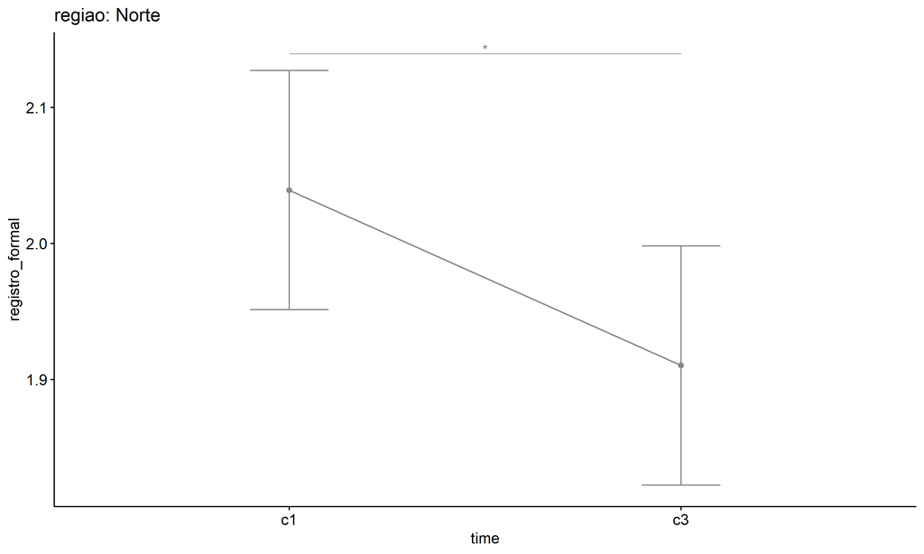

```r
emms.gg <- emms[which(emms$regiao == "Norte"),]
if (nrow(emms.gg) > 0)
  ggline(emms.gg, x = "time", y = "emmean", color = "#868686FF", ylab = "registro_formal") +
    geom_errorbar(aes(ymin = conf.low, ymax = conf.high),
                  width = 0.2, color = "#868686FF") +
    stat_pvalue_manual(
      add_xy_position(pwc[which(pwc$regiao == "Norte"),],
                      x = "time", fun = "mean_se"),
      hide.ns = T, color = "#868686FF", tip.length = F) +
    labs(title = "regiao: Norte")+
    theme(legend.text = element_blank())
```

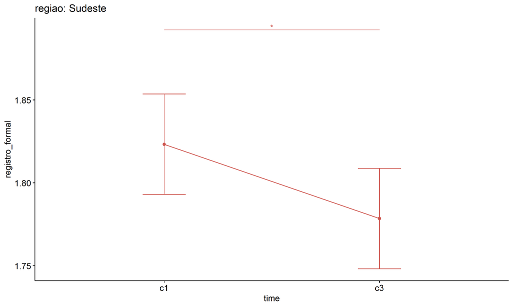

```r
emms.gg <- emms[which(emms$regiao == "Sudeste"),]
if (nrow(emms.gg) > 0)
  ggline(emms.gg, x = "time", y = "emmean", color = "#CD534CFF", ylab = "registro_formal") +
    geom_errorbar(aes(ymin = conf.low, ymax = conf.high),
                  width = 0.2, color = "#CD534CFF") +
    stat_pvalue_manual(
      add_xy_position(pwc[which(pwc$regiao == "Sudeste"),],
                      x = "time", fun = "mean_se"),
      hide.ns = T, color = "#CD534CFF", tip.length = F) +
    labs(title = "regiao: Sudeste")+
    theme(legend.text = element_blank())
```

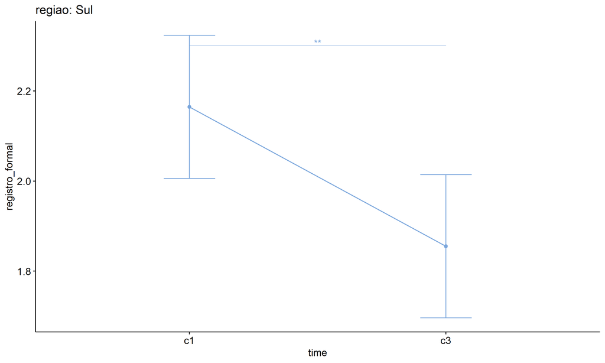

```r
emms.gg <- emms[which(emms$regiao == "Sul"),]
if (nrow(emms.gg) > 0)
  ggline(emms.gg, x = "time", y = "emmean", color = "#7AA6DCFF", ylab = "registro_formal") +
    geom_errorbar(aes(ymin = conf.low, ymax = conf.high),
                  width = 0.2, color = "#7AA6DCFF") +
    stat_pvalue_manual(
      add_xy_position(pwc[which(pwc$regiao == "Sul"),],
                      x = "time", fun = "mean_se"),
      hide.ns = T, color = "#7AA6DCFF", tip.length = F) +
    labs(title = "regiao: Sul")+
    theme(legend.text = element_blank())
```

## PairWise Computation after removing non.normal data

```r
if (length(non.ids) > 0)
  (pwc2 <- ldat2 %>% group_by(time) %>%
     emmeans_test(registro_formal ~ regiao, detailed = T, p.adjust.method = "bonferroni"))
```

```r
if (length(non.ids) > 0)
  (emms2 <- get_emmeans(pwc2))
```

```r
if (length(non.ids) > 0) {
  pwc2 <- add_xy_position(pwc2, x = "time", fun = "mean_se", dodge = 0.25)
  pd2 <- position_dodge(width = 0.25)

  ggline(emms2, x = "time", y = "emmean", color = "regiao",
         palette = c("#0073C2FF","#EFC000FF","#868686FF","#CD534CFF","#7AA6DCFF"),
         position = pd, ylab = "registro_formal") +
    geom_errorbar(aes(ymin = conf.low, ymax = conf.high, color = regiao),
                position = pd, width = 0.2) +
    stat_pvalue_manual(pwc2, hide.ns = T, tip.length = F, linetype = 1)
}
```

```r
if (length(non.ids) > 0)
  (pwc2 <- ldat2 %>% group_by(regiao) %>%
     emmeans_test(registro_formal ~ time, detailed = T, p.adjust.method = "bonferroni"))
```

```r
if (length(non.ids) > 0)
  (emms2 <- get_emmeans(pwc2))
```

```r
if (length(non.ids) > 0) {
  emms.gg <- emms2[which(emms2$regiao == "Centro-Oeste"),]
  if (nrow(emms.gg) > 0)
    ggline(emms.gg, x = "time", y = "emmean", color = "#0073C2FF", ylab = "registro_formal") +
    geom_errorbar(aes(ymin = conf.low, ymax = conf.high),
                  width = 0.2, color = "#0073C2FF") +
    stat_pvalue_manual(
      add_xy_position(pwc[which(pwc$regiao == "Centro-Oeste"),],
                      x = "time", fun = "mean_se"),
      hide.ns = T, color = "#0073C2FF", tip.length = F) +
    labs(title = "regiao: Centro-Oeste") +
    theme(legend.text = element_blank())
}
```

```r
if (length(non.ids) > 0) {
  emms.gg <- emms2[which(emms2$regiao == "Nordeste"),]
  if (nrow(emms.gg) > 0)
    ggline(emms.gg, x = "time", y = "emmean", color = "#EFC000FF", ylab = "registro_formal") +
    geom_errorbar(aes(ymin = conf.low, ymax = conf.high),
                  width = 0.2, color = "#EFC000FF") +
    stat_pvalue_manual(
      add_xy_position(pwc[which(pwc$regiao == "Nordeste"),],
                      x = "time", fun = "mean_se"),
      hide.ns = T, color = "#EFC000FF", tip.length = F) +
    labs(title = "regiao: Nordeste") +
    theme(legend.text = element_blank())
}
```

```r
if (length(non.ids) > 0) {
  emms.gg <- emms2[which(emms2$regiao == "Norte"),]
  if (nrow(emms.gg) > 0)
    ggline(emms.gg, x = "time", y = "emmean", color = "#868686FF", ylab = "registro_formal") +
    geom_errorbar(aes(ymin = conf.low, ymax = conf.high),
                  width = 0.2, color = "#868686FF") +
    stat_pvalue_manual(
      add_xy_position(pwc[which(pwc$regiao == "Norte"),],
                      x = "time", fun = "mean_se"),
      hide.ns = T, color = "#868686FF", tip.length = F) +
    labs(title = "regiao: Norte") +
    theme(legend.text = element_blank())
}
```

```r
if (length(non.ids) > 0) {
  emms.gg <- emms2[which(emms2$regiao == "Sudeste"),]
  if (nrow(emms.gg) > 0)
    ggline(emms.gg, x = "time", y = "emmean", color = "#CD534CFF", ylab = "registro_formal") +
    geom_errorbar(aes(ymin = conf.low, ymax = conf.high),
                  width = 0.2, color = "#CD534CFF") +
    stat_pvalue_manual(
      add_xy_position(pwc[which(pwc$regiao == "Sudeste"),],
                      x = "time", fun = "mean_se"),
      hide.ns = T, color = "#CD534CFF", tip.length = F) +
    labs(title = "regiao: Sudeste") +
    theme(legend.text = element_blank())
}
```

```r
if (length(non.ids) > 0) {
  emms.gg <- emms2[which(emms2$regiao == "Sul"),]
  if (nrow(emms.gg) > 0)
    ggline(emms.gg, x = "time", y = "emmean", color = "#7AA6DCFF", ylab = "registro_formal") +
    geom_errorbar(aes(ymin = conf.low, ymax = conf.high),
                  width = 0.2, color = "#7AA6DCFF") +
    stat_pvalue_manual(
      add_xy_position(pwc[which(pwc$regiao == "Sul"),],
                      x = "time", fun = "mean_se"),
      hide.ns = T, color = "#7AA6DCFF", tip.length = F) +
    labs(title = "regiao: Sul") +
    theme(legend.text = element_blank())
}
```

# ANOVA: registro_formal ~ time*porte + Error(id/time)

## Data Preparation

```r
data <- edat[,c("aluno_id","porte","ciclo","registro_formal")]
data <- data[data$ciclo %in% c("Primeiro Ciclo","Terceiro Ciclo"),]
data$ciclo <- factor(data$ciclo, c("Primeiro Ciclo","Terceiro Ciclo"))
data <- unique(data)

wdat <- spread(data, ciclo, registro_formal)
wdat <- wdat[complete.cases(wdat),]
colnames(wdat) <- c("id","porte","c1","c3")

ldat <- gather(wdat, key = time, value = registro_formal, c1,c3) %>%
  convert_as_factor(id, time)
ldat <- remove_group_data(ldat, "registro_formal", c("time", "porte"), n.limit = 30)
ldat$porte <- factor(ldat$porte, sort(unique(ldat$porte)))
```

### Check assumptions: Identifying Outliers

```r
outliers <- identify_outliers(group_by(ldat, time, porte), registro_formal)
(outliers <- outliers[outliers$is.extreme == T,])
```

```
## # A tibble: 22 × 6
##    porte                       time  id    registro_formal is.outlier is.extreme
##    <fct>                       <fct> <fct>           <dbl> <lgl>      <lgl>
##  1 Entre 501 e 1000 matrícula… c1    bait…               4 TRUE       TRUE
##  2 Entre 501 e 1000 matrícula… c1    cWE8…               4 TRUE       TRUE
##  3 Entre 501 e 1000 matrícula… c1    htby…               4 TRUE       TRUE
##  4 Entre 501 e 1000 matrícula… c1    IS6H…               4 TRUE       TRUE
##  5 Entre 501 e 1000 matrícula… c1    iyHs…               4 TRUE       TRUE
##  6 Entre 501 e 1000 matrícula… c1    K7BV…               4 TRUE       TRUE
##  7 Entre 501 e 1000 matrícula… c1    KaCG…               4 TRUE       TRUE
##  8 Entre 501 e 1000 matrícula… c1    KsND…               4 TRUE       TRUE
##  9 Entre 501 e 1000 matrícula… c1    Kxut…               4 TRUE       TRUE
## 10 Entre 501 e 1000 matrícula… c1    lcQk…               4 TRUE       TRUE
## # ℹ 12 more rows
```

| porte | time | id | registro_formal | is.outlier | is.extreme |
| --- | --- | --- | --- | --- | --- |
| Entre 501 e 1000 matrículas de escolarização | c1 | baitWvlruSoQV9MUrIgr | 4 | TRUE | TRUE |
| Entre 501 e 1000 matrículas de escolarização | c1 | cWE83pbQy4poly6i3xSL | 4 | TRUE | TRUE |
| Entre 501 e 1000 matrículas de escolarização | c1 | htbyM16UJUtyqr6P6Jfi | 4 | TRUE | TRUE |
| Entre 501 e 1000 matrículas de escolarização | c1 | IS6H8SGCc2Qi3Sc76Hdu | 4 | TRUE | TRUE |
| Entre 501 e 1000 matrículas de escolarização | c1 | iyHsVjMJJRSYypImpewF | 4 | TRUE | TRUE |
| Entre 501 e 1000 matrículas de escolarização | c1 | K7BVRqiiNsRjisKvt85x | 4 | TRUE | TRUE |
| Entre 501 e 1000 matrículas de escolarização | c1 | KaCG3CroQpZookJ14Oed | 4 | TRUE | TRUE |
| Entre 501 e 1000 matrículas de escolarização | c1 | KsNDea9pyWSqZNmzKPcL | 4 | TRUE | TRUE |
| Entre 501 e 1000 matrículas de escolarização | c1 | KxutDWOwf7c7zs3WzsVK | 4 | TRUE | TRUE |
| Entre 501 e 1000 matrículas de escolarização | c1 | lcQkFKelmfF3AvUDkp2E | 4 | TRUE | TRUE |
| Entre 501 e 1000 matrículas de escolarização | c1 | nqxuyy3NvKzRwok1AiGQ | 4 | TRUE | TRUE |
| Entre 501 e 1000 matrículas de escolarização | c1 | NXvel6ktXlJ6LeTLisl6 | 4 | TRUE | TRUE |
| Entre 501 e 1000 matrículas de escolarização | c1 | qapU5TnFRgKOIiu6Mhxr | 4 | TRUE | TRUE |
| Entre 501 e 1000 matrículas de escolarização | c1 | sIoy2GB8m7C2p6qtFBB4 | 4 | TRUE | TRUE |
| Entre 501 e 1000 matrículas de escolarização | c1 | tmFRnwP1EI4qeDkRvZDt | 4 | TRUE | TRUE |
| Entre 501 e 1000 matrículas de escolarização | c1 | UqLUlHER7l3QQ8FNufkX | 4 | TRUE | TRUE |
| Entre 501 e 1000 matrículas de escolarização | c1 | wCRkCrxzSKzu3xtWPtn3 | 4 | TRUE | TRUE |
| Entre 501 e 1000 matrículas de escolarização | c1 | WliDxeLsUXTgNB5sq98e | 4 | TRUE | TRUE |
| Entre 501 e 1000 matrículas de escolarização | c1 | XifeitosHzGsyw8Rt5o3 | 4 | TRUE | TRUE |
| Entre 501 e 1000 matrículas de escolarização | c1 | XqDnfcg1NBKmeeKWYgH6 | 4 | TRUE | TRUE |
| Entre 501 e 1000 matrículas de escolarização | c1 | Z3wZBU0s09KRxFHiK8eK | 4 | TRUE | TRUE |
| Entre 501 e 1000 matrículas de escolarização | c1 | ZQGZhiLTqE3hv9N29HCv | 4 | TRUE | TRUE |

### Check assumptions: Normality Test

```r
(normality.df <- normality.test.per.groups(ldat, "registro_formal", c("time", "porte")))
```

```
##               var        variable time
## 1 registro_formal registro_formal   c1
## 2 registro_formal registro_formal   c1
## 3 registro_formal registro_formal   c1
## 4 registro_formal registro_formal   c1
## 5 registro_formal registro_formal   c3
## 6 registro_formal registro_formal   c3
## 7 registro_formal registro_formal   c3
## 8 registro_formal registro_formal   c3
##                                          porte    n  skewness     kurtosis
## 1  Entre 201 e 500 matrículas de escolarização 1059 0.3279917 -0.338882612
## 2 Entre 501 e 1000 matrículas de escolarização 2315 0.6091623  0.028906891
## 3   Entre 51 e 200 matrículas de escolarização  259 0.1348769 -0.758935794
## 4     Mais de 1000 matrículas de escolarização  344 0.5986510 -0.438786607
## 5  Entre 201 e 500 matrículas de escolarização 1059 0.3246562 -0.439721652
## 6 Entre 501 e 1000 matrículas de escolarização 2315 0.6902749 -0.009493163
## 7   Entre 51 e 200 matrículas de escolarização  259 0.6012544  0.259741759
## 8     Mais de 1000 matrículas de escolarização  344 0.8642430  0.264336376
##   symmetry statistic     method            p p.signif normality
## 1      YES  25.02633 D'Agostino 3.677921e-06     ****         -
## 2       NO 123.69529 D'Agostino 0.000000e+00     ****         -
## 3      YES  15.05234 D'Agostino 5.387987e-04       **         -
## 4       NO  22.25393 D'Agostino 1.471024e-05      ***         -
## 5      YES  31.22865 D'Agostino 1.654947e-07     ****         -
## 6       NO 152.98960 D'Agostino 0.000000e+00     ****         -
## 7       NO  15.58229 D'Agostino 4.133789e-04       **         -
## 8       NO  35.91138 D'Agostino 1.591997e-08     ****         -
```

| var | variable | time | porte | n | skewness | kurtosis | symmetry | statistic | method | p | p.signif | normality |
| --- | --- | --- | --- | --- | --- | --- | --- | --- | --- | --- | --- | --- |
| registro_formal | registro_formal | c1 | Entre 201 e 500 matrículas de escolarização | 1059 | 0.328 | -0.339 | YES | 25.026 | D’Agostino | 0.000 | **** | - |
| registro_formal | registro_formal | c1 | Entre 501 e 1000 matrículas de escolarização | 2315 | 0.609 | 0.029 | NO | 123.695 | D’Agostino | 0.000 | **** | - |
| registro_formal | registro_formal | c1 | Entre 51 e 200 matrículas de escolarização | 259 | 0.135 | -0.759 | YES | 15.052 | D’Agostino | 0.001 | ** | - |
| registro_formal | registro_formal | c1 | Mais de 1000 matrículas de escolarização | 344 | 0.599 | -0.439 | NO | 22.254 | D’Agostino | 0.000 | *** | - |
| registro_formal | registro_formal | c3 | Entre 201 e 500 matrículas de escolarização | 1059 | 0.325 | -0.440 | YES | 31.229 | D’Agostino | 0.000 | **** | - |
| registro_formal | registro_formal | c3 | Entre 501 e 1000 matrículas de escolarização | 2315 | 0.690 | -0.009 | NO | 152.990 | D’Agostino | 0.000 | **** | - |
| registro_formal | registro_formal | c3 | Entre 51 e 200 matrículas de escolarização | 259 | 0.601 | 0.260 | NO | 15.582 | D’Agostino | 0.000 | ** | - |
| registro_formal | registro_formal | c3 | Mais de 1000 matrículas de escolarização | 344 | 0.864 | 0.264 | NO | 35.911 | D’Agostino | 0.000 | **** | - |

```r
(non.ids <- unique(do.call(
  c, lapply(which(normality.df$normality == 'NO'), FUN = function(i) {
  idx = which(ldat$time == normality.df$time[i] &
                ldat$porte == normality.df$porte[i])
  getNonNormal(ldat$"registro_formal"[idx], ldat$id[idx])
}))))
```

```r
if (length(non.ids) > 0)
  ldat2 <- ldat[!ldat$id %in% non.ids,]
```

### Summary Statistics

```r
(sdat <- ldat %>% group_by(time, porte) %>%
   get_summary_stats(registro_formal, type = "mean_sd"))
```

```
## # A tibble: 8 × 6
##   porte                                        time  variable      n  mean    sd
##   <fct>                                        <fct> <fct>     <dbl> <dbl> <dbl>
## 1 Entre 201 e 500 matrículas de escolarização  c1    registro…  1059  1.99 0.7
## 2 Entre 501 e 1000 matrículas de escolarização c1    registro…  2315  1.84 0.667
## 3 Entre 51 e 200 matrículas de escolarização   c1    registro…   259  2.09 0.718
## 4 Mais de 1000 matrículas de escolarização     c1    registro…   344  1.78 0.685
## 5 Entre 201 e 500 matrículas de escolarização  c3    registro…  1059  1.98 0.737
## 6 Entre 501 e 1000 matrículas de escolarização c3    registro…  2315  1.75 0.714
## 7 Entre 51 e 200 matrículas de escolarização   c3    registro…   259  1.92 0.739
## 8 Mais de 1000 matrículas de escolarização     c3    registro…   344  1.70 0.74
```

| porte | time | variable | n | mean | sd |
| --- | --- | --- | --- | --- | --- |
| Entre 201 e 500 matrículas de escolarização | c1 | registro_formal | 1059 | 1.986 | 0.700 |
| Entre 501 e 1000 matrículas de escolarização | c1 | registro_formal | 2315 | 1.835 | 0.667 |
| Entre 51 e 200 matrículas de escolarização | c1 | registro_formal | 259 | 2.091 | 0.718 |
| Mais de 1000 matrículas de escolarização | c1 | registro_formal | 344 | 1.783 | 0.685 |
| Entre 201 e 500 matrículas de escolarização | c3 | registro_formal | 1059 | 1.979 | 0.737 |
| Entre 501 e 1000 matrículas de escolarização | c3 | registro_formal | 2315 | 1.751 | 0.714 |
| Entre 51 e 200 matrículas de escolarização | c3 | registro_formal | 259 | 1.923 | 0.739 |
| Mais de 1000 matrículas de escolarização | c3 | registro_formal | 344 | 1.705 | 0.740 |

```r
if (length(non.ids) > 0)
  (sdat <- ldat2 %>% group_by(time, porte) %>%
      get_summary_stats(registro_formal, type = "mean_sd"))
```

[output not shown]

## ANOVA Computation

```r
(res.aov <- anova_test(ldat, dv = registro_formal, wid = id, between = porte, within = time))
```

```
## ANOVA Table (type III tests)
##
##       Effect DFn  DFd      F        p p<.05      ges
## 1      porte   3 3973 45.063 1.25e-28     * 0.018000
## 2       time   1 3973 15.447 8.63e-05     * 0.002000
## 3 porte:time   3 3973  2.646 4.70e-02     * 0.000912
```

## ANOVA Computation after removing non.normal data

```r
if (length(non.ids) > 0)
  (res.aov2 <- anova_test(ldat2, dv = registro_formal, wid = id, between = porte , within = time))
```

## PairWise Computation

```r
(pwc <- ldat %>% group_by(time) %>%
   emmeans_test(registro_formal ~ porte, detailed = T, p.adjust.method = "bonferroni"))
```

```
## # A tibble: 12 × 15
##    time  term  .y.       group1 group2 null.value estimate     se    df conf.low
##  * <fct> <chr> <chr>     <chr>  <chr>       <dbl>    <dbl>  <dbl> <dbl>    <dbl>
##  1 c1    porte registro… Entre… Entre…          0   0.151  0.0261  7946   0.0995
##  2 c1    porte registro… Entre… Entre…          0  -0.105  0.0487  7946  -0.201
##  3 c1    porte registro… Entre… Mais …          0   0.202  0.0436  7946   0.117
##  4 c1    porte registro… Entre… Entre…          0  -0.256  0.0460  7946  -0.346
##  5 c1    porte registro… Entre… Mais …          0   0.0516 0.0406  7946  -0.0280
##  6 c1    porte registro… Entre… Mais …          0   0.307  0.0578  7946   0.194
##  7 c3    porte registro… Entre… Entre…          0   0.228  0.0261  7946   0.177
##  8 c3    porte registro… Entre… Entre…          0   0.0553 0.0487  7946  -0.0402
##  9 c3    porte registro… Entre… Mais …          0   0.274  0.0436  7946   0.188
## 10 c3    porte registro… Entre… Entre…          0  -0.173  0.0460  7946  -0.263
## 11 c3    porte registro… Entre… Mais …          0   0.0458 0.0406  7946  -0.0338
## 12 c3    porte registro… Entre… Mais …          0   0.218  0.0578  7946   0.105
## # ℹ 5 more variables: conf.high <dbl>, statistic <dbl>, p <dbl>, p.adj <dbl>,
## #   p.adj.signif <chr>
```

| time | term | .y. | group1 | group2 | null.value | estimate | se | df | conf.low | conf.high | statistic | p | p.adj | p.adj.signif |
| --- | --- | --- | --- | --- | --- | --- | --- | --- | --- | --- | --- | --- | --- | --- |
| c1 | porte | registro_formal | Entre 201 e 500 matrículas de escolarização | Entre 501 e 1000 matrículas de escolarização | 0 | 0.151 | 0.026 | 7946 | 0.100 | 0.202 | 5.778 | 0.000 | 0.000 | **** |
| c1 | porte | registro_formal | Entre 201 e 500 matrículas de escolarização | Entre 51 e 200 matrículas de escolarização | 0 | -0.105 | 0.049 | 7946 | -0.201 | -0.010 | -2.158 | 0.031 | 0.186 | ns |
| c1 | porte | registro_formal | Entre 201 e 500 matrículas de escolarização | Mais de 1000 matrículas de escolarização | 0 | 0.202 | 0.044 | 7946 | 0.117 | 0.288 | 4.636 | 0.000 | 0.000 | **** |
| c1 | porte | registro_formal | Entre 501 e 1000 matrículas de escolarização | Entre 51 e 200 matrículas de escolarização | 0 | -0.256 | 0.046 | 7946 | -0.346 | -0.165 | -5.555 | 0.000 | 0.000 | **** |
| c1 | porte | registro_formal | Entre 501 e 1000 matrículas de escolarização | Mais de 1000 matrículas de escolarização | 0 | 0.052 | 0.041 | 7946 | -0.028 | 0.131 | 1.270 | 0.204 | 1.000 | ns |
| c1 | porte | registro_formal | Entre 51 e 200 matrículas de escolarização | Mais de 1000 matrículas de escolarização | 0 | 0.307 | 0.058 | 7946 | 0.194 | 0.421 | 5.316 | 0.000 | 0.000 | **** |
| c3 | porte | registro_formal | Entre 201 e 500 matrículas de escolarização | Entre 501 e 1000 matrículas de escolarização | 0 | 0.228 | 0.026 | 7946 | 0.177 | 0.279 | 8.746 | 0.000 | 0.000 | **** |
| c3 | porte | registro_formal | Entre 201 e 500 matrículas de escolarização | Entre 51 e 200 matrículas de escolarização | 0 | 0.055 | 0.049 | 7946 | -0.040 | 0.151 | 1.136 | 0.256 | 1.000 | ns |
| c3 | porte | registro_formal | Entre 201 e 500 matrículas de escolarização | Mais de 1000 matrículas de escolarização | 0 | 0.274 | 0.044 | 7946 | 0.188 | 0.359 | 6.279 | 0.000 | 0.000 | **** |
| c3 | porte | registro_formal | Entre 501 e 1000 matrículas de escolarização | Entre 51 e 200 matrículas de escolarização | 0 | -0.173 | 0.046 | 7946 | -0.263 | -0.082 | -3.750 | 0.000 | 0.001 | ** |
| c3 | porte | registro_formal | Entre 501 e 1000 matrículas de escolarização | Mais de 1000 matrículas de escolarização | 0 | 0.046 | 0.041 | 7946 | -0.034 | 0.125 | 1.128 | 0.259 | 1.000 | ns |
| c3 | porte | registro_formal | Entre 51 e 200 matrículas de escolarização | Mais de 1000 matrículas de escolarização | 0 | 0.218 | 0.058 | 7946 | 0.105 | 0.332 | 3.779 | 0.000 | 0.001 | *** |

```r
(emms <- get_emmeans(pwc))
```

```
## # A tibble: 8 × 8
##   time  porte                      emmean     se    df conf.low conf.high method
##   <fct> <fct>                       <dbl>  <dbl> <dbl>    <dbl>     <dbl> <chr>
## 1 c1    Entre 201 e 500 matrícula…   1.99 0.0216  7946     1.94      2.03 Emmea…
## 2 c1    Entre 501 e 1000 matrícul…   1.83 0.0146  7946     1.81      1.86 Emmea…
## 3 c1    Entre 51 e 200 matrículas…   2.09 0.0437  7946     2.01      2.18 Emmea…
## 4 c1    Mais de 1000 matrículas d…   1.78 0.0379  7946     1.71      1.86 Emmea…
## 5 c3    Entre 201 e 500 matrícula…   1.98 0.0216  7946     1.94      2.02 Emmea…
## 6 c3    Entre 501 e 1000 matrícul…   1.75 0.0146  7946     1.72      1.78 Emmea…
## 7 c3    Entre 51 e 200 matrículas…   1.92 0.0437  7946     1.84      2.01 Emmea…
## 8 c3    Mais de 1000 matrículas d…   1.70 0.0379  7946     1.63      1.78 Emmea…
```

| time | porte | emmean | se | df | conf.low | conf.high | method |
| --- | --- | --- | --- | --- | --- | --- | --- |
| c1 | Entre 201 e 500 matrículas de escolarização | 1.986 | 0.022 | 7946 | 1.943 | 2.028 | Emmeans test |
| c1 | Entre 501 e 1000 matrículas de escolarização | 1.835 | 0.015 | 7946 | 1.806 | 1.864 | Emmeans test |
| c1 | Entre 51 e 200 matrículas de escolarização | 2.091 | 0.044 | 7946 | 2.005 | 2.176 | Emmeans test |
| c1 | Mais de 1000 matrículas de escolarização | 1.783 | 0.038 | 7946 | 1.709 | 1.858 | Emmeans test |
| c3 | Entre 201 e 500 matrículas de escolarização | 1.979 | 0.022 | 7946 | 1.936 | 2.021 | Emmeans test |
| c3 | Entre 501 e 1000 matrículas de escolarização | 1.751 | 0.015 | 7946 | 1.722 | 1.779 | Emmeans test |
| c3 | Entre 51 e 200 matrículas de escolarização | 1.923 | 0.044 | 7946 | 1.838 | 2.009 | Emmeans test |
| c3 | Mais de 1000 matrículas de escolarização | 1.705 | 0.038 | 7946 | 1.631 | 1.779 | Emmeans test |

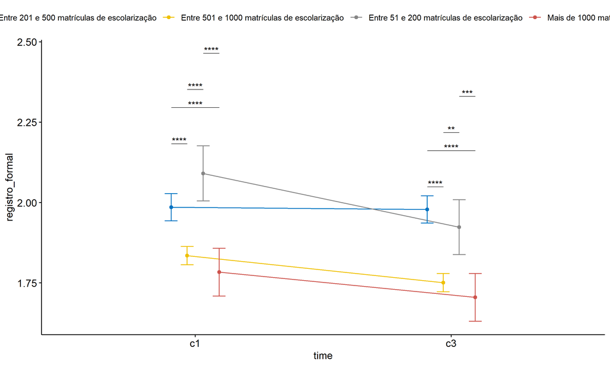

```r
pwc <- add_xy_position(pwc, x = "time", fun = "mean_se", dodge = 0.25)
pd <- position_dodge(width = 0.25)
ggline(emms, x = "time", y = "emmean", color = "porte",
       palette = c("#0073C2FF","#EFC000FF","#868686FF","#CD534CFF","#7AA6DCFF"),
       position = pd, ylab = "registro_formal") +
  geom_errorbar(aes(ymin = conf.low, ymax = conf.high, color = porte),
                position = pd, width = 0.2) +
  stat_pvalue_manual(pwc, hide.ns = T, tip.length = F, linetype = 1)
```

```r
(pwc <- ldat %>% group_by(porte) %>%
    emmeans_test(registro_formal ~ time, detailed = T, p.adjust.method = "bonferroni"))
```

```
## # A tibble: 4 × 15
##   porte      term  .y.   group1 group2 null.value estimate     se    df conf.low
## * <fct>      <chr> <chr> <chr>  <chr>       <dbl>    <dbl>  <dbl> <dbl>    <dbl>
## 1 Entre 201… time  regi… c1     c3              0  0.00685 0.0305  7946  -0.0530
## 2 Entre 501… time  regi… c1     c3              0  0.0842  0.0207  7946   0.0437
## 3 Entre 51 … time  regi… c1     c3              0  0.167   0.0617  7946   0.0463
## 4 Mais de 1… time  regi… c1     c3              0  0.0785  0.0536  7946  -0.0265
## # ℹ 5 more variables: conf.high <dbl>, statistic <dbl>, p <dbl>, p.adj <dbl>,
## #   p.adj.signif <chr>
```

| porte | term | .y. | group1 | group2 | null.value | estimate | se | df | conf.low | conf.high | statistic | p | p.adj | p.adj.signif |
| --- | --- | --- | --- | --- | --- | --- | --- | --- | --- | --- | --- | --- | --- | --- |
| Entre 201 e 500 matrículas de escolarização | time | registro_formal | c1 | c3 | 0 | 0.007 | 0.031 | 7946 | -0.053 | 0.067 | 0.224 | 0.823 | 0.823 | ns |
| Entre 501 e 1000 matrículas de escolarização | time | registro_formal | c1 | c3 | 0 | 0.084 | 0.021 | 7946 | 0.044 | 0.125 | 4.078 | 0.000 | 0.000 | **** |
| Entre 51 e 200 matrículas de escolarização | time | registro_formal | c1 | c3 | 0 | 0.167 | 0.062 | 7946 | 0.046 | 0.288 | 2.710 | 0.007 | 0.007 | ** |
| Mais de 1000 matrículas de escolarização | time | registro_formal | c1 | c3 | 0 | 0.078 | 0.054 | 7946 | -0.027 | 0.184 | 1.465 | 0.143 | 0.143 | ns |

```r
(emms <- get_emmeans(pwc))
```

```
## # A tibble: 8 × 8
##   porte                      time  emmean     se    df conf.low conf.high method
##   <fct>                      <fct>  <dbl>  <dbl> <dbl>    <dbl>     <dbl> <chr>
## 1 Entre 201 e 500 matrícula… c1      1.99 0.0216  7946     1.94      2.03 Emmea…
## 2 Entre 201 e 500 matrícula… c3      1.98 0.0216  7946     1.94      2.02 Emmea…
## 3 Entre 501 e 1000 matrícul… c1      1.83 0.0146  7946     1.81      1.86 Emmea…
## 4 Entre 501 e 1000 matrícul… c3      1.75 0.0146  7946     1.72      1.78 Emmea…
## 5 Entre 51 e 200 matrículas… c1      2.09 0.0437  7946     2.01      2.18 Emmea…
## 6 Entre 51 e 200 matrículas… c3      1.92 0.0437  7946     1.84      2.01 Emmea…
## 7 Mais de 1000 matrículas d… c1      1.78 0.0379  7946     1.71      1.86 Emmea…
## 8 Mais de 1000 matrículas d… c3      1.70 0.0379  7946     1.63      1.78 Emmea…
```

| porte | time | emmean | se | df | conf.low | conf.high | method |
| --- | --- | --- | --- | --- | --- | --- | --- |
| Entre 201 e 500 matrículas de escolarização | c1 | 1.986 | 0.022 | 7946 | 1.943 | 2.028 | Emmeans test |
| Entre 201 e 500 matrículas de escolarização | c3 | 1.979 | 0.022 | 7946 | 1.936 | 2.021 | Emmeans test |
| Entre 501 e 1000 matrículas de escolarização | c1 | 1.835 | 0.015 | 7946 | 1.806 | 1.864 | Emmeans test |
| Entre 501 e 1000 matrículas de escolarização | c3 | 1.751 | 0.015 | 7946 | 1.722 | 1.779 | Emmeans test |
| Entre 51 e 200 matrículas de escolarização | c1 | 2.091 | 0.044 | 7946 | 2.005 | 2.176 | Emmeans test |
| Entre 51 e 200 matrículas de escolarização | c3 | 1.923 | 0.044 | 7946 | 1.838 | 2.009 | Emmeans test |
| Mais de 1000 matrículas de escolarização | c1 | 1.783 | 0.038 | 7946 | 1.709 | 1.858 | Emmeans test |
| Mais de 1000 matrículas de escolarização | c3 | 1.705 | 0.038 | 7946 | 1.631 | 1.779 | Emmeans test |

```r
emms.gg <- emms[which(emms$porte == "Até 50 matrículas de escolarização"),]
if (nrow(emms.gg) > 0)
  ggline(emms.gg, x = "time", y = "emmean", color = "#0073C2FF", ylab = "registro_formal") +
    geom_errorbar(aes(ymin = conf.low, ymax = conf.high),
                  width = 0.2, color = "#0073C2FF") +
    stat_pvalue_manual(
      add_xy_position(pwc[which(pwc$porte == "Até 50 matrículas de escolarização"),],
                      x = "time", fun = "mean_se"),
      hide.ns = T, color = "#0073C2FF", tip.length = F) +
    labs(title = "porte: Até 50 matrículas de escolarização")+
    theme(legend.text = element_blank())
```

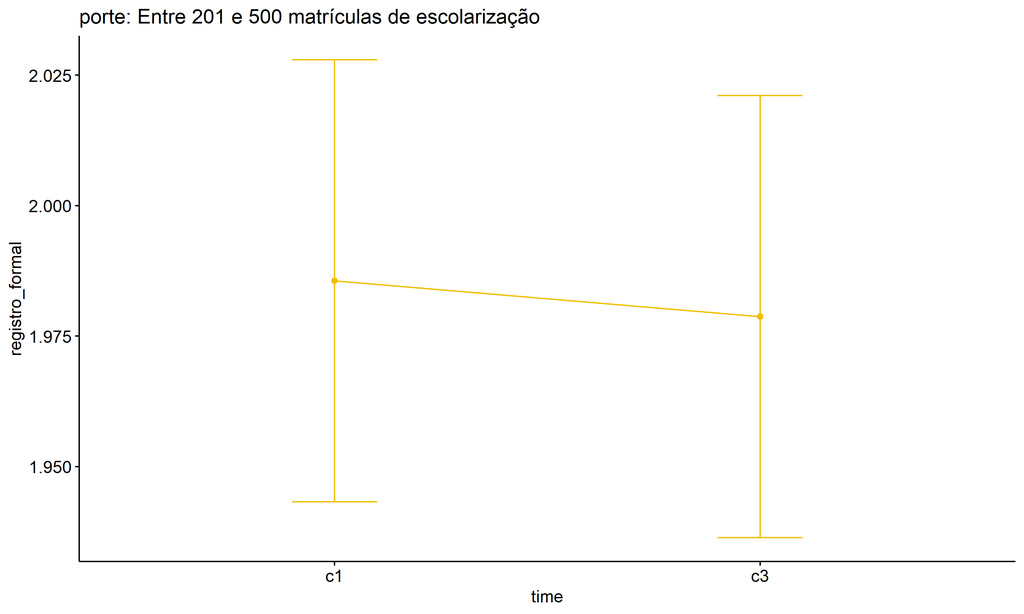

```r
emms.gg <- emms[which(emms$porte == "Entre 201 e 500 matrículas de escolarização"),]
if (nrow(emms.gg) > 0)
  ggline(emms.gg, x = "time", y = "emmean", color = "#EFC000FF", ylab = "registro_formal") +
    geom_errorbar(aes(ymin = conf.low, ymax = conf.high),
                  width = 0.2, color = "#EFC000FF") +
    stat_pvalue_manual(
      add_xy_position(pwc[which(pwc$porte == "Entre 201 e 500 matrículas de escolarização"),],
                      x = "time", fun = "mean_se"),
      hide.ns = T, color = "#EFC000FF", tip.length = F) +
    labs(title = "porte: Entre 201 e 500 matrículas de escolarização")+
    theme(legend.text = element_blank())
```

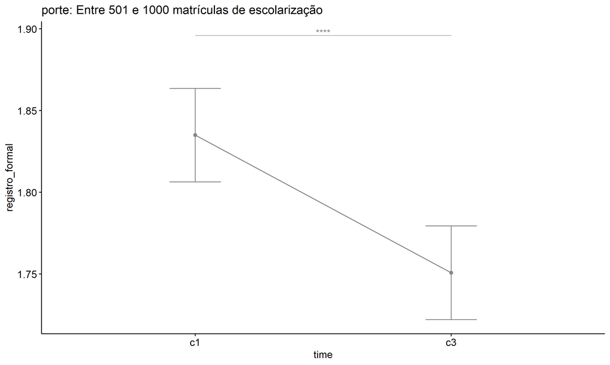

```r
emms.gg <- emms[which(emms$porte == "Entre 501 e 1000 matrículas de escolarização"),]
if (nrow(emms.gg) > 0)
  ggline(emms.gg, x = "time", y = "emmean", color = "#868686FF", ylab = "registro_formal") +
    geom_errorbar(aes(ymin = conf.low, ymax = conf.high),
                  width = 0.2, color = "#868686FF") +
    stat_pvalue_manual(
      add_xy_position(pwc[which(pwc$porte == "Entre 501 e 1000 matrículas de escolarização"),],
                      x = "time", fun = "mean_se"),
      hide.ns = T, color = "#868686FF", tip.length = F) +
    labs(title = "porte: Entre 501 e 1000 matrículas de escolarização")+
    theme(legend.text = element_blank())
```

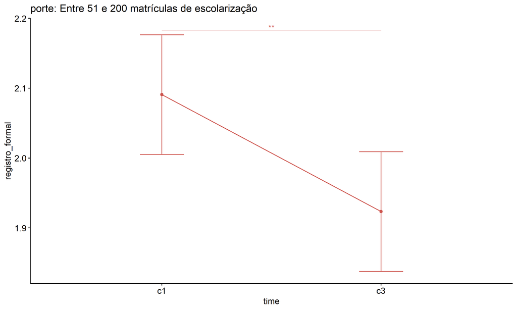

```r
emms.gg <- emms[which(emms$porte == "Entre 51 e 200 matrículas de escolarização"),]
if (nrow(emms.gg) > 0)
  ggline(emms.gg, x = "time", y = "emmean", color = "#CD534CFF", ylab = "registro_formal") +
    geom_errorbar(aes(ymin = conf.low, ymax = conf.high),
                  width = 0.2, color = "#CD534CFF") +
    stat_pvalue_manual(
      add_xy_position(pwc[which(pwc$porte == "Entre 51 e 200 matrículas de escolarização"),],
                      x = "time", fun = "mean_se"),
      hide.ns = T, color = "#CD534CFF", tip.length = F) +
    labs(title = "porte: Entre 51 e 200 matrículas de escolarização")+
    theme(legend.text = element_blank())
```

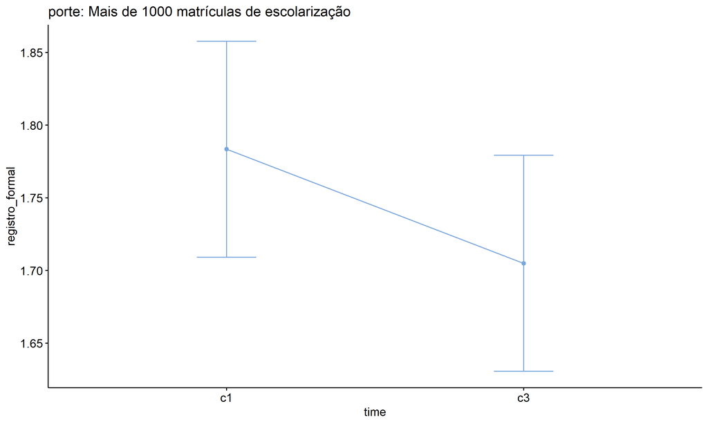

```r
emms.gg <- emms[which(emms$porte == "Mais de 1000 matrículas de escolarização"),]
if (nrow(emms.gg) > 0)
  ggline(emms.gg, x = "time", y = "emmean", color = "#7AA6DCFF", ylab = "registro_formal") +
    geom_errorbar(aes(ymin = conf.low, ymax = conf.high),
                  width = 0.2, color = "#7AA6DCFF") +
    stat_pvalue_manual(
      add_xy_position(pwc[which(pwc$porte == "Mais de 1000 matrículas de escolarização"),],
                      x = "time", fun = "mean_se"),
      hide.ns = T, color = "#7AA6DCFF", tip.length = F) +
    labs(title = "porte: Mais de 1000 matrículas de escolarização")+
    theme(legend.text = element_blank())
```

## PairWise Computation after removing non.normal data

```r
if (length(non.ids) > 0)
  (pwc2 <- ldat2 %>% group_by(time) %>%
     emmeans_test(registro_formal ~ porte, detailed = T, p.adjust.method = "bonferroni"))
```

```r
if (length(non.ids) > 0)
  (emms2 <- get_emmeans(pwc2))
```

```r
if (length(non.ids) > 0) {
  pwc2 <- add_xy_position(pwc2, x = "time", fun = "mean_se", dodge = 0.25)
  pd2 <- position_dodge(width = 0.25)

  ggline(emms2, x = "time", y = "emmean", color = "porte",
         palette = c("#0073C2FF","#EFC000FF","#868686FF","#CD534CFF","#7AA6DCFF"),
         position = pd, ylab = "registro_formal") +
    geom_errorbar(aes(ymin = conf.low, ymax = conf.high, color = porte),
                position = pd, width = 0.2) +
    stat_pvalue_manual(pwc2, hide.ns = T, tip.length = F, linetype = 1)
}
```

```r
if (length(non.ids) > 0)
  (pwc2 <- ldat2 %>% group_by(porte) %>%
     emmeans_test(registro_formal ~ time, detailed = T, p.adjust.method = "bonferroni"))
```

```r
if (length(non.ids) > 0)
  (emms2 <- get_emmeans(pwc2))
```

```r
if (length(non.ids) > 0) {
  emms.gg <- emms2[which(emms2$porte == "Até 50 matrículas de escolarização"),]
  if (nrow(emms.gg) > 0)
    ggline(emms.gg, x = "time", y = "emmean", color = "#0073C2FF", ylab = "registro_formal") +
    geom_errorbar(aes(ymin = conf.low, ymax = conf.high),
                  width = 0.2, color = "#0073C2FF") +
    stat_pvalue_manual(
      add_xy_position(pwc[which(pwc$porte == "Até 50 matrículas de escolarização"),],
                      x = "time", fun = "mean_se"),
      hide.ns = T, color = "#0073C2FF", tip.length = F) +
    labs(title = "porte: Até 50 matrículas de escolarização") +
    theme(legend.text = element_blank())
}
```

```r
if (length(non.ids) > 0) {
  emms.gg <- emms2[which(emms2$porte == "Entre 201 e 500 matrículas de escolarização"),]
  if (nrow(emms.gg) > 0)
    ggline(emms.gg, x = "time", y = "emmean", color = "#EFC000FF", ylab = "registro_formal") +
    geom_errorbar(aes(ymin = conf.low, ymax = conf.high),
                  width = 0.2, color = "#EFC000FF") +
    stat_pvalue_manual(
      add_xy_position(pwc[which(pwc$porte == "Entre 201 e 500 matrículas de escolarização"),],
                      x = "time", fun = "mean_se"),
      hide.ns = T, color = "#EFC000FF", tip.length = F) +
    labs(title = "porte: Entre 201 e 500 matrículas de escolarização") +
    theme(legend.text = element_blank())
}
```

```r
if (length(non.ids) > 0) {
  emms.gg <- emms2[which(emms2$porte == "Entre 501 e 1000 matrículas de escolarização"),]
  if (nrow(emms.gg) > 0)
    ggline(emms.gg, x = "time", y = "emmean", color = "#868686FF", ylab = "registro_formal") +
    geom_errorbar(aes(ymin = conf.low, ymax = conf.high),
                  width = 0.2, color = "#868686FF") +
    stat_pvalue_manual(
      add_xy_position(pwc[which(pwc$porte == "Entre 501 e 1000 matrículas de escolarização"),],
                      x = "time", fun = "mean_se"),
      hide.ns = T, color = "#868686FF", tip.length = F) +
    labs(title = "porte: Entre 501 e 1000 matrículas de escolarização") +
    theme(legend.text = element_blank())
}
```

```r
if (length(non.ids) > 0) {
  emms.gg <- emms2[which(emms2$porte == "Entre 51 e 200 matrículas de escolarização"),]
  if (nrow(emms.gg) > 0)
    ggline(emms.gg, x = "time", y = "emmean", color = "#CD534CFF", ylab = "registro_formal") +
    geom_errorbar(aes(ymin = conf.low, ymax = conf.high),
                  width = 0.2, color = "#CD534CFF") +
    stat_pvalue_manual(
      add_xy_position(pwc[which(pwc$porte == "Entre 51 e 200 matrículas de escolarização"),],
                      x = "time", fun = "mean_se"),
      hide.ns = T, color = "#CD534CFF", tip.length = F) +
    labs(title = "porte: Entre 51 e 200 matrículas de escolarização") +
    theme(legend.text = element_blank())
}
```

```r
if (length(non.ids) > 0) {
  emms.gg <- emms2[which(emms2$porte == "Mais de 1000 matrículas de escolarização"),]
  if (nrow(emms.gg) > 0)
    ggline(emms.gg, x = "time", y = "emmean", color = "#7AA6DCFF", ylab = "registro_formal") +
    geom_errorbar(aes(ymin = conf.low, ymax = conf.high),
                  width = 0.2, color = "#7AA6DCFF") +
    stat_pvalue_manual(
      add_xy_position(pwc[which(pwc$porte == "Mais de 1000 matrículas de escolarização"),],
                      x = "time", fun = "mean_se"),
      hide.ns = T, color = "#7AA6DCFF", tip.length = F) +
    labs(title = "porte: Mais de 1000 matrículas de escolarização") +
    theme(legend.text = element_blank())
}
```